# Longitudinal Analysis of Glycaemic Trajectories in Type 2 Diabetes Mellitus

Linear Mixed Effects Model (LMM) and Generalised Estimating Equations (GEE) | GET503 Advanced Numerical Data Analysis | DrPH Epidemiology | Universiti Sains Malaysia

Authors

Siti Nurhafizah binti Saharudin

Ahmad Zulfahmi bin Sha’ari

Nazirul Munir bin Abu Hassan

Mohd Fittri Fahmi bin Fauzi

Published

June 10, 2026

# Overview & Study Background

## Assignment Details

| Item | Detail |
| --- | --- |
| **Assignment** | GET503 Advanced Numerical Data Analysis |
| **Programme** | Doctor of Public Health (DrPH) Epidemiology |
| **Institution** | Universiti Sains Malaysia |
| **Methods** | Linear Mixed Effects Model (LMM) & Generalised Estimating Equations (GEE) |
| **Outcome** | HbA1c (%), longitudinal, 3 time points |
| **Sample** | 20,000 T2DM patients × 3 waves = 60,000 observations |
| **Data source** | [Kaggle: T2DM Longitudinal Treatment Outcomes](https://www.kaggle.com/datasets/sahilrana034/t2dm-longitudinal-treatment-outcomes) |

## Background

Type 2 Diabetes Mellitus (T2DM) is a chronic metabolic disease characterised by persistent hyperglycaemia and remains a leading cause of cardiovascular disease, renal failure, and premature mortality worldwide. In Malaysia, T2DM constitutes a growing public health burden, with national prevalence estimates exceeding 18% of the adult population. Glycated haemoglobin (HbA1c), reflecting average blood glucose over the preceding two to three months, is the primary clinical marker used to monitor long-term glycaemic control. Reducing HbA1c through targeted lifestyle and pharmacological interventions is a central goal of T2DM management at both the individual clinical and population levels.

This analysis utilises a longitudinal dataset of **20,000 T2DM patients**, each measured at three structured time points, pre-intervention (T1_Pre), mid-intervention (T2_Mid), and post-intervention (T3_Post), capturing a wide range of patient-level characteristics including demographics, lifestyle behaviours, clinical markers, and intervention type. Because each patient contributes three repeated measurements, standard multiple linear regression (MLR) is inappropriate: observations from the same patient are inherently correlated, violating the independence assumption. Two complementary longitudinal methods address this, the **Linear Mixed Effects Model (LMM)** and **Generalised Estimating Equations (GEE)**, which differ fundamentally in their estimand and interpretation:

- **LMM** models *subject-specific* effects. It directly estimates how each patient’s HbA1c changes over time by incorporating patient-level random effects, making it ideal for understanding individual trajectories and quantifying between-patient heterogeneity.
- **GEE** models *population-averaged* effects. It estimates the expected HbA1c change for an average patient in the population, making its coefficients directly interpretable for public health policy and programme evaluation.

Both analyses follow the **REAAAPP** workflow (**R**ead → **E**DA → **A**ssumptions → **A**nalyse → **A**ssess → **P**resent → **P**ublish), ensuring a structured, reproducible, and transparent analytical process.

## Research Question & Objectives

**Primary Research Question**

Among patients with Type 2 Diabetes Mellitus, do different intervention strengths (Weak, Standard, Intensive) produce different trajectories of HbA1c change over time, after adjusting for demographic, lifestyle, and clinical covariates?

**Primary Objective**

To determine whether intervention strength (Weak, Standard, Intensive) produces significantly different HbA1c trajectories over time, using both LMM (subject-specific estimates) and GEE (population-averaged estimates).

**Secondary Objectives**

1. To quantify the overall change in HbA1c over time, independent of intervention group or patient characteristics (unconditional growth model: LMM).
2. To identify patient-level demographic, lifestyle, and clinical factors independently associated with HbA1c in both the LMM and GEE frameworks.
3. To estimate and compare adjusted mean HbA1c at each time point across intervention groups using estimated marginal means (EMMs), and to determine whether all three intervention groups differ significantly from each other at the study endpoint.
4. To select the optimal working correlation structure for GEE using the Quasi-likelihood under Independence Criterion (QIC) and evaluate structural sensitivity through cross-structure comparison.

## Study Variables

**Outcome variable**

| Variable | Type | Description |
| --- | --- | --- |
| `hba1c` | Continuous | HbA1c (%), primary measure of glycaemic control; the dependent variable in all models |

**Time variable**

| Variable | Type | Description |
| --- | --- | --- |
| `time_step` | Ordered factor | Study time point: T1_Pre (baseline), T2_Mid, T3_Post |
| `time_num` | Numeric (0/1/2) | Numeric encoding of time, required for the random slope model |

**Primary exposure (intervention)**

| Variable | Type | Levels |
| --- | --- | --- |
| `intervention_strength` | Ordered factor | Weak *(ref)*, Standard, Intensive |

**Demographic covariates**

| Variable | Type | Description |
| --- | --- | --- |
| `age` | Continuous | Age in years |
| `gender` | Factor | Female *(ref)*, Male |

**Lifestyle covariates**

| Variable | Type | Description |
| --- | --- | --- |
| `physical_activity_level` | Ordered factor | Low *(ref)*, Moderate, High |
| `diet_score` | Continuous | Dietary quality score; higher = better |
| `sleep_hours` | Continuous | Average daily sleep (hours) |

**Clinical covariates**

| Variable | Type | Description |
| --- | --- | --- |
| `bmi` | Continuous | Body Mass Index (kg/m²) |
| `medication_adherence` | Ordered factor | Poor *(ref)*, Moderate, Good |
| `comorbidity_level` | Ordered factor | Low *(ref)*, Medium, High |

**Administrative variables**

| Variable | Type | Description |
| --- | --- | --- |
| `patient_id` | Factor | Unique patient identifier; used as the random-intercept grouping variable in LMM and the cluster ID in GEE |

# 1 Data Preparation & Exploratory Analysis

This section covers the **R**ead and **E**xplore steps of the REAAAPP framework. All packages are loaded upfront, the shared dataset is prepared once, and exploratory analyses are conducted before any modelling. This sequence ensures that any data quality issues are identified and resolved prior to inference.

## 1.1 R: Package Setup

All required packages are loaded using `pacman::p_load()`, which installs any missing packages automatically. The combined package set supports data wrangling, EDA, LMM fitting, GEE fitting, post-estimation, and publication-quality visualisation.

```r
if (!require("pacman")) install.packages("pacman")

pacman::p_load(
  # Data management
  tidyverse, janitor, here,
  # EDA
  skimr, DataExplorer, corrplot,
  # Tables
  gtsummary, gt, kableExtra,
  # Model output
  broom, broom.mixed, broom.helpers,
  # LMM
  lme4, lmerTest, sjPlot, performance, MuMIn,
  # GEE
  geepack,
  # Post-estimation
  emmeans, car, lmtest, MASS,
  # Visualisation
  ggplot2, patchwork, scales,
  # Utilities
  rstatix, purrr
)

# ── Okabe & Ito (2008) colourblind-safe palette ──────────────
cb_intervention <- c(
  "Weak"      = "#E69F00",
  "Standard"  = "#56B4E9",
  "Intensive" = "#0072B2"
)
cb_time <- c(
  "T1_Pre"  = "#56B4E9",
  "T2_Mid"  = "#009E73",
  "T3_Post" = "#0072B2"
)

# ── Shared ggplot2 theme ──────────────────────────────────────
theme_gee <- function(base_size = 12) {
  theme_bw(base_size = base_size) %+replace%
    theme(
      panel.grid.minor  = element_blank(),
      panel.border      = element_rect(colour = "#cdd8e6"),
      plot.title        = element_text(face = "bold", size = base_size + 1,
                                       colour = "#1a1c2e"),
      plot.subtitle     = element_text(colour = "#3d4560", size = base_size - 1),
      legend.position   = "bottom",
      legend.key.size   = unit(0.75, "lines"),
      legend.title      = element_text(face = "bold"),
      strip.background  = element_rect(fill = "#e6f1fb"),
      strip.text        = element_text(face = "bold", colour = "#0b2d5e"),
      axis.title        = element_text(face = "bold", size = base_size - 0.5),
      axis.text         = element_text(colour = "#3d4560")
    )
}
```

## 1.2 R: Data Loading & Preparation

The cleaned dataset is loaded from `t2dm_clean.csv`. Factor levels are encoded explicitly to ensure correct reference categories and ordering throughout all subsequent models. Gender uses **Female** as the reference category. The dataset is sorted by `patient_id` and `time_num`, a requirement for `geepack` to correctly identify within-cluster observation order.

**ImportantBefore Rendering: Set Your Data Path**

Update `data_path` in the chunk below to the full path of your `t2dm_clean.csv` file if it is **not** in the same folder as this `.qmd` file. For example:

```
data_path <- "C:/Users/User/Documents/MyProject/t2dm_clean.csv"
```

```r
# ── ✏️  SET THIS PATH to your t2dm_clean.csv location ────────
# If the CSV is in the same folder as this .qmd, leave as-is.
# Otherwise, provide the full file path, e.g.:
#   data_path <- "C:/Users/User/Documents/t2dm_clean.csv"
data_path <- "t2dm_clean.csv"

df <- read_csv(data_path) |>
  mutate(
    patient_id = factor(patient_id),
    # Numeric time index (0, 1, 2) - required for random slope models
    time_num = as.numeric(factor(time_step,
               levels = c("T1_Pre", "T2_Mid", "T3_Post"))) - 1,

    # Ordered factors - reference category is the first (clinically worst) level
    time_step = factor(time_step,
                  levels = c("T1_Pre", "T2_Mid", "T3_Post")),
    intervention_strength = factor(intervention_strength,
                  levels = c("Weak", "Standard", "Intensive")),
    physical_activity_level = factor(physical_activity_level,
                  levels = c("Low", "Moderate", "High")),
    medication_adherence = factor(medication_adherence,
                  levels = c("Poor", "Moderate", "Good")),
    comorbidity_level = factor(comorbidity_level,
                  levels = c("Low", "Medium", "High")),
    gender = factor(gender, levels = c("Female", "Male"))
  ) |>
  # CRITICAL for GEE: data must be sorted by cluster ID then time
  arrange(patient_id, time_num)

cat(sprintf("Observations : %d\n", nrow(df)))
```

```
Observations : 60000
```

```r
cat(sprintf("Patients     : %d\n", n_distinct(df$patient_id)))
```

```
Patients     : 20000
```

```r
cat(sprintf("Time points  : %d per patient (balanced)\n",
            nrow(df) / n_distinct(df$patient_id)))
```

```
Time points  : 3 per patient (balanced)
```

```r
cat(sprintf("HbA1c range  : %.2f - %.2f %%\n",
            min(df$hba1c), max(df$hba1c)))
```

```
HbA1c range  : 4.60 - 13.13 %
```

```r
cat("=== Dataset Structure (glimpse) ===\n")
```

```
=== Dataset Structure (glimpse) ===
```

```r
glimpse(df)
```

```
Rows: 60,000
Columns: 14
$ patient_id              <fct> 1, 1, 1, 2, 2, 2, 3, 3, 3, 4, 4, 4, 5, 5, 5, 6…
$ time_step               <fct> T1_Pre, T2_Mid, T3_Post, T1_Pre, T2_Mid, T3_Po…
$ age                     <dbl> 73, 73, 73, 72, 72, 72, 68, 68, 68, 51, 51, 51…
$ gender                  <fct> Male, Male, Male, Female, Female, Female, Male…
$ bmi                     <dbl> 32.96, 31.77, 30.94, 23.06, 23.25, 22.46, 36.2…
$ hba1c                   <dbl> 7.12, 5.83, 4.78, 11.30, 11.41, 11.46, 7.76, 7…
$ physical_activity_level <fct> High, High, High, Low, Low, Low, High, High, H…
$ diet_score              <dbl> 8.2, 8.9, 9.8, 7.2, 7.2, 6.9, 3.4, 3.5, 4.2, 5…
$ sleep_hours             <dbl> 4.0, 4.6, 4.6, 6.7, 6.3, 6.1, 7.6, 7.5, 7.6, 7…
$ medication_adherence    <fct> Good, Good, Good, Moderate, Poor, Poor, Poor, …
$ intervention_strength   <fct> Standard, Standard, Standard, Standard, Standa…
$ comorbidity_level       <fct> Medium, Medium, Medium, Medium, Medium, Medium…
$ time_index              <dbl> 0, 1, 2, 0, 1, 2, 0, 1, 2, 0, 1, 2, 0, 1, 2, 0…
$ time_num                <dbl> 0, 1, 2, 0, 1, 2, 0, 1, 2, 0, 1, 2, 0, 1, 2, 0…
```

**NoteData Structure Confirmation**

## 1.3 E: Exploratory Data Analysis

### 1.3.1 Data Quality Summary

Three complementary checks confirm data integrity before modelling: `skimr::skim()` provides a full distributional profile of all variables; `colSums(is.na())` counts missing values per column; and `DataExplorer::plot_missing()` visualises the missingness pattern.

```r
skimr::skim(df)
```

Data summary

| Name | df |
| --- | --- |
| Number of rows | 60000 |
| Number of columns | 14 |
| _______________________ |  |
| Column type frequency: |  |
| factor | 7 |
| numeric | 7 |
| ________________________ |  |
| Group variables | None |

**Variable type: factor**

| skim_variable | n_missing | complete_rate | ordered | n_unique | top_counts |
| --- | --- | --- | --- | --- | --- |
| patient_id | 0 | 1 | FALSE | 20000 | 1: 3, 2: 3, 3: 3, 4: 3 |
| time_step | 0 | 1 | FALSE | 3 | T1_: 20000, T2_: 20000, T3_: 20000 |
| gender | 0 | 1 | FALSE | 2 | Mal: 30525, Fem: 29475 |
| physical_activity_level | 0 | 1 | FALSE | 3 | Low: 23899, Mod: 18950, Hig: 17151 |
| medication_adherence | 0 | 1 | FALSE | 3 | Goo: 27386, Poo: 16486, Mod: 16128 |
| intervention_strength | 0 | 1 | FALSE | 3 | Sta: 28761, Int: 18297, Wea: 12942 |
| comorbidity_level | 0 | 1 | FALSE | 3 | Med: 26085, Low: 21207, Hig: 12708 |

**Variable type: numeric**

| skim_variable | n_missing | complete_rate | mean | sd | p0 | p25 | p50 | p75 | p100 | hist |
| --- | --- | --- | --- | --- | --- | --- | --- | --- | --- | --- |
| age | 0 | 1 | 53.05 | 14.71 | 28.0 | 40.00 | 53.00 | 66.00 | 78.00 | ▇▇▇▇▇ |
| bmi | 0 | 1 | 31.31 | 4.87 | 18.0 | 28.05 | 31.28 | 34.66 | 47.55 | ▁▆▇▃▁ |
| hba1c | 0 | 1 | 8.34 | 1.31 | 4.6 | 7.48 | 8.38 | 9.24 | 13.13 | ▁▆▇▂▁ |
| diet_score | 0 | 1 | 5.45 | 1.83 | 1.0 | 4.20 | 5.40 | 6.70 | 10.00 | ▂▆▇▅▂ |
| sleep_hours | 0 | 1 | 6.67 | 1.05 | 4.0 | 5.90 | 6.70 | 7.40 | 9.50 | ▂▆▇▅▁ |
| time_index | 0 | 1 | 1.00 | 0.82 | 0.0 | 0.00 | 1.00 | 2.00 | 2.00 | ▇▁▇▁▇ |
| time_num | 0 | 1 | 1.00 | 0.82 | 0.0 | 0.00 | 1.00 | 2.00 | 2.00 | ▇▁▇▁▇ |

```r
colSums(is.na(df))
```

```
             patient_id               time_step                     age
                      0                       0                       0
                 gender                     bmi                   hba1c
                      0                       0                       0
physical_activity_level              diet_score             sleep_hours
                      0                       0                       0
   medication_adherence   intervention_strength       comorbidity_level
                      0                       0                       0
             time_index                time_num
                      0                       0
```

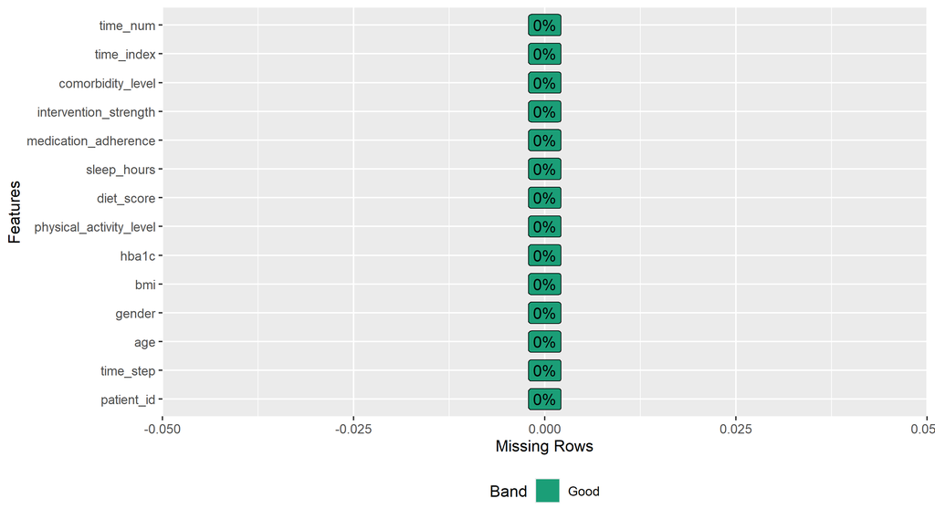

```r
DataExplorer::plot_missing(df)
```

### 1.3.2 Balance Check

A longitudinal dataset is **balanced** if every subject contributes the same number of observations at the same time points. This check confirms that each of the 20,000 patients appears exactly three times (once per time point), ruling out phantom rows, duplicate entries, or missing visits that would complicate subsequent analysis.

```r
df |> count(time_step)                 # expect 20,000 per time point
```

| time_step | n |
| --- | --- |
| T1_Pre | 20000 |
| T2_Mid | 20000 |
| T3_Post | 20000 |

```r
df |> count(patient_id) |> summary()  # expect min = max = 3
```

```
   patient_id          n
 1      :    1   Min.   :3
 2      :    1   1st Qu.:3
 3      :    1   Median :3
 4      :    1   Mean   :3
 5      :    1   3rd Qu.:3
 6      :    1   Max.   :3
 (Other):19994
```

A perfectly balanced panel means no complications from unequal cluster sizes. Both LMM and GEE handle unbalanced data, but confirmed balance rules out data entry issues and ensures the ICCand QIC computations reflect the intended design.

### 1.3.3 Spaghetti Plot: Individual Trajectories

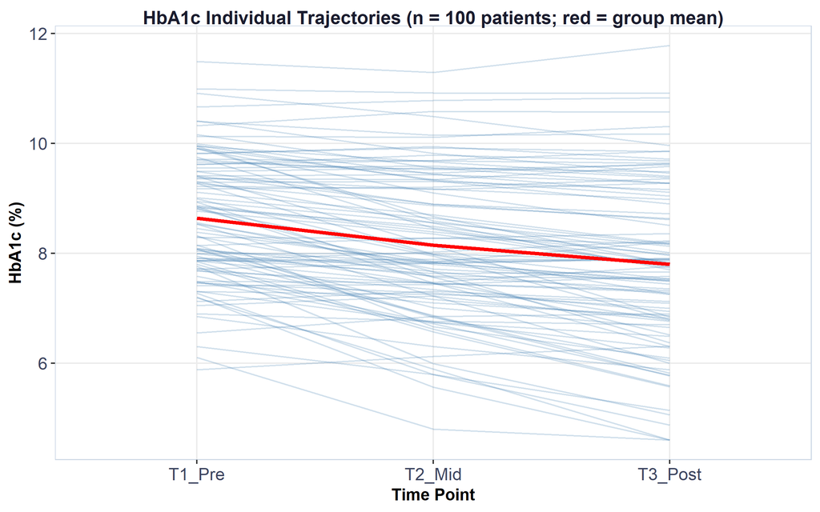

Figure 1: Figure 1. HbA1c individual and mean trajectories across three time points (n = 100 randomly sampled patients; red line = group mean). Wide spread of blue lines indicates substantial between-patient heterogeneity in baseline HbA1c, the primary justification for including random effects in LMM.

```r
set.seed(123)
sample_pts <- sample(levels(df$patient_id), 100)

ggplot(df |> filter(patient_id %in% sample_pts),
       aes(x = time_step, y = hba1c, group = patient_id)) +
  geom_line(alpha = 0.25, colour = "steelblue") +
  stat_summary(aes(group = 1), fun = mean, geom = "line",
               colour = "red", linewidth = 1.2) +
  labs(title = "HbA1c Individual Trajectories (n = 100 patients; red = group mean)",
       x = "Time Point", y = "HbA1c (%)") +
  theme_gee()
```

A descending red mean line confirms HbA1c improves on average over time. The wide spread of individual blue lines demonstrates strong **between-patient heterogeneity** in baseline HbA1c, quantified later by the ICC. Lines that cross (non-parallel trajectories) suggest patients also differ in their rate of change, motivating the random slope extension in LMM.

### 1.3.4 Mean Trajectory by Intervention Strength

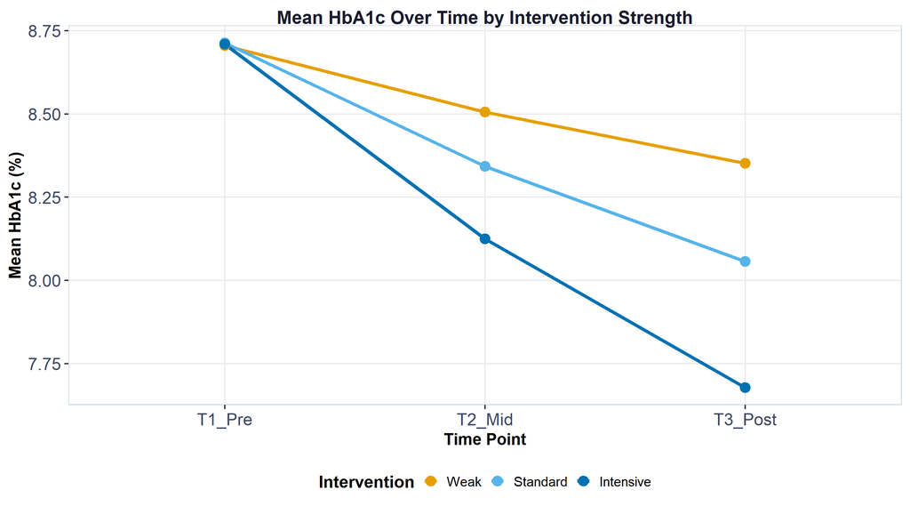

Figure 2: Figure 2. Mean HbA1c over time by intervention strength. Diverging lines indicate a Time × Intervention interaction: the effect of intervention on HbA1c differs across time points, motivating interaction models in both LMM and GEE.

```r
df |>
  group_by(time_step, intervention_strength) |>
  summarise(mean_hba1c = mean(hba1c), .groups = "drop") |>
  ggplot(aes(x = time_step, y = mean_hba1c,
             colour = intervention_strength, group = intervention_strength)) +
  geom_line(linewidth = 1.2) +
  geom_point(size = 3) +
  scale_colour_manual(values = cb_intervention) +
  labs(title = "Mean HbA1c Over Time by Intervention Strength",
       x = "Time Point", y = "Mean HbA1c (%)",
       colour = "Intervention") +
  theme_gee()
```

If lines run **parallel**, there is no interaction, the intervention effect is constant across time points. Diverging lines (Intensive dropping fastest) signal a **time × intervention interaction**: the benefit of higher-intensity intervention accumulates over time, which will be formally tested in both the LMM and GEE interaction models.

### 1.3.5 HbA1c Distribution by Group

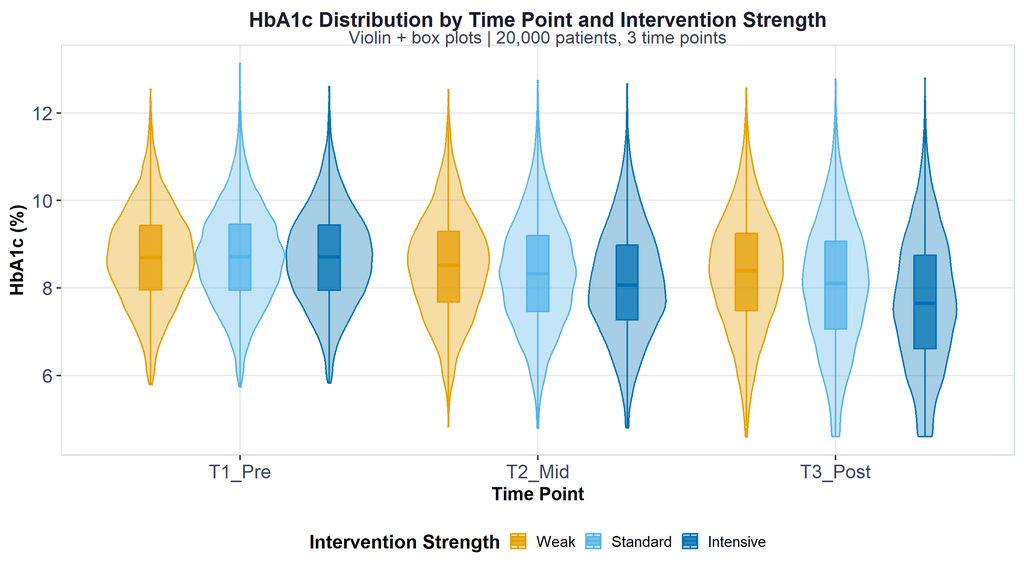

Figure 3: Figure 3. Distribution of HbA1c (%) by time point and intervention strength (n = 60,000 observations). Violin + box plots reveal distributional shape, spread, and temporal trend simultaneously. Colourblind-safe palette (Okabe & Ito, 2008).

```r
df |>
  ggplot(aes(x = time_step, y = hba1c,
             fill = intervention_strength,
             colour = intervention_strength)) +
  geom_violin(alpha = 0.35, trim = TRUE, linewidth = 0.5) +
  geom_boxplot(alpha = 0.75, width = 0.22, outlier.size = 0.3,
               position = position_dodge(0.9)) +
  scale_fill_manual(values = cb_intervention, name = "Intervention Strength") +
  scale_colour_manual(values = cb_intervention, name = "Intervention Strength") +
  labs(
    title    = "HbA1c Distribution by Time Point and Intervention Strength",
    subtitle = "Violin + box plots | 20,000 patients, 3 time points",
    x = "Time Point", y = "HbA1c (%)"
  ) +
  theme_gee()
```

**TipFigure 3 Interpretation**

### 1.3.6 Correlation Matrix

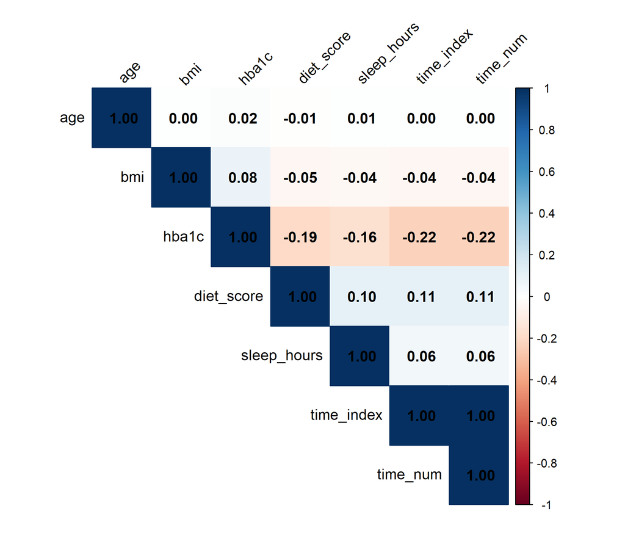

Figure 4: Figure 4. Pairwise Pearson correlations among all continuous variables. Colour intensity indicates strength (blue = positive, red = negative). Pairs with |r| > 0.8 would signal multicollinearity requiring variable removal.

```r
cont_vars <- df |>
  dplyr::select(where(is.double))

cor_matrix <- cor(as.matrix(cont_vars), use = "complete.obs")
corrplot::corrplot(cor_matrix, method = "color", type = "upper",
                   addCoef.col = "black", tl.col = "black", tl.srt = 45)
```

### 1.3.7 Table 1: Baseline Patient Characteristics

```r
df |>
  filter(time_step == "T1_Pre") |>
  dplyr::select(age, gender, bmi, hba1c,
                physical_activity_level, diet_score, sleep_hours,
                medication_adherence, intervention_strength,
                comorbidity_level) |>
  tbl_summary(
    statistic = list(
      all_continuous()  ~ "{mean} ({sd})",
      all_categorical() ~ "{n} ({p}%)"
    ),
    missing = "no",
    label = list(
      age                     ~ "Age (years)",
      gender                  ~ "Gender",
      hba1c                   ~ "HbA1c (%)",
      bmi                     ~ "BMI (kg/m²)",
      diet_score              ~ "Diet Score",
      sleep_hours             ~ "Sleep Hours",
      physical_activity_level ~ "Physical Activity Level",
      medication_adherence    ~ "Medication Adherence",
      intervention_strength   ~ "Intervention Strength",
      comorbidity_level       ~ "Comorbidity Level"
    )
  ) |>
  bold_labels() |>
  modify_caption("**Table 1. Baseline Characteristics at T1_Pre (n = 20,000)**")
```

**Table 1. Baseline Characteristics at T1_Pre (n = 20,000)**

| **Characteristic** | **N = 20,000**<sup>1</sup> |
| --- | --- |
| Age (years) | 53 (15) |
| Gender |  |
| Female | 9,825 (49%) |
| Male | 10,175 (51%) |
| BMI (kg/m²) | 31.6 (4.8) |
| HbA1c (%) | 8.71 (1.10) |
| Physical Activity Level |  |
| Low | 8,022 (40%) |
| Moderate | 7,624 (38%) |
| High | 4,354 (22%) |
| Diet Score | 5.20 (1.70) |
| Sleep Hours | 6.60 (1.00) |
| Medication Adherence |  |
| Poor | 4,720 (24%) |
| Moderate | 6,851 (34%) |
| Good | 8,429 (42%) |
| Intervention Strength |  |
| Weak | 4,314 (22%) |
| Standard | 9,587 (48%) |
| Intensive | 6,099 (30%) |
| Comorbidity Level |  |
| Low | 7,069 (35%) |
| Medium | 8,695 (43%) |
| High | 4,236 (21%) |

<sup>1</sup> Mean (SD); n (%)

Table 1 characterises the study cohort at baseline (T1_Pre only). Filtering to baseline is essential, including all three time points would inflate n to 60,000, misrepresenting the actual cohort size of 20,000 patients. This table establishes the starting point before any intervention effects have occurred.

### 1.3.8 Table 2: Longitudinal Descriptive Statistics by Time Point

```r
df |>
  dplyr::select(hba1c, time_step, intervention_strength,
                age, gender, bmi, physical_activity_level,
                diet_score, sleep_hours, medication_adherence,
                comorbidity_level) |>
  tbl_summary(
    by = time_step,
    statistic = list(
      all_continuous()  ~ "{mean} ({sd})",
      all_categorical() ~ "{n} ({p}%)"
    ),
    digits = list(
      all_continuous()  ~ 2,
      all_categorical() ~ c(0, 1)
    ),
    label = list(
      hba1c                   ~ "HbA1c (%)",
      intervention_strength   ~ "Intervention Strength",
      age                     ~ "Age (years)",
      gender                  ~ "Gender",
      bmi                     ~ "BMI (kg/m²)",
      physical_activity_level ~ "Physical Activity Level",
      diet_score              ~ "Diet Score",
      sleep_hours             ~ "Sleep Hours",
      medication_adherence    ~ "Medication Adherence",
      comorbidity_level       ~ "Comorbidity Level"
    ),
    missing = "no"
  ) |>
  add_overall() |>
  bold_labels() |>
  modify_header(label ~ "**Variable**") |>
  modify_caption("**Table 2. Descriptive Characteristics by Time Point (n = 60,000 observations)**")
```

**Table 2. Descriptive Characteristics by Time Point (n = 60,000 observations)**

| **Variable** | **Overall** N = 60,000<sup>1</sup> | **T1_Pre** N = 20,000<sup>1</sup> | **T2_Mid** N = 20,000<sup>1</sup> | **T3_Post** N = 20,000<sup>1</sup> |
| --- | --- | --- | --- | --- |
| HbA1c (%) | 8.34 (1.31) | 8.71 (1.10) | 8.31 (1.25) | 8.00 (1.46) |
| Intervention Strength |  |  |  |  |
| Weak | 12,942 (21.6%) | 4,314 (21.6%) | 4,314 (21.6%) | 4,314 (21.6%) |
| Standard | 28,761 (47.9%) | 9,587 (47.9%) | 9,587 (47.9%) | 9,587 (47.9%) |
| Intensive | 18,297 (30.5%) | 6,099 (30.5%) | 6,099 (30.5%) | 6,099 (30.5%) |
| Age (years) | 53.05 (14.71) | 53.05 (14.71) | 53.05 (14.71) | 53.05 (14.71) |
| Gender |  |  |  |  |
| Female | 29,475 (49.1%) | 9,825 (49.1%) | 9,825 (49.1%) | 9,825 (49.1%) |
| Male | 30,525 (50.9%) | 10,175 (50.9%) | 10,175 (50.9%) | 10,175 (50.9%) |
| BMI (kg/m²) | 31.31 (4.87) | 31.57 (4.82) | 31.31 (4.86) | 31.06 (4.92) |
| Physical Activity Level |  |  |  |  |
| Low | 23,899 (39.8%) | 8,022 (40.1%) | 7,763 (38.8%) | 8,114 (40.6%) |
| Moderate | 18,950 (31.6%) | 7,624 (38.1%) | 6,035 (30.2%) | 5,291 (26.5%) |
| High | 17,151 (28.6%) | 4,354 (21.8%) | 6,202 (31.0%) | 6,595 (33.0%) |
| Diet Score | 5.45 (1.83) | 5.20 (1.70) | 5.49 (1.82) | 5.67 (1.93) |
| Sleep Hours | 6.67 (1.05) | 6.60 (1.00) | 6.68 (1.05) | 6.74 (1.10) |
| Medication Adherence |  |  |  |  |
| Poor | 16,486 (27.5%) | 4,720 (23.6%) | 5,573 (27.9%) | 6,193 (31.0%) |
| Moderate | 16,128 (26.9%) | 6,851 (34.3%) | 4,927 (24.6%) | 4,350 (21.8%) |
| Good | 27,386 (45.6%) | 8,429 (42.1%) | 9,500 (47.5%) | 9,457 (47.3%) |
| Comorbidity Level |  |  |  |  |
| Low | 21,207 (35.3%) | 7,069 (35.3%) | 7,069 (35.3%) | 7,069 (35.3%) |
| Medium | 26,085 (43.5%) | 8,695 (43.5%) | 8,695 (43.5%) | 8,695 (43.5%) |
| High | 12,708 (21.2%) | 4,236 (21.2%) | 4,236 (21.2%) | 4,236 (21.2%) |

<sup>1</sup> Mean (SD); n (%)

**TipTable 2 Interpretation**

Mean HbA1c declined progressively from 8.71% at baseline to 8.00% post-intervention, suggesting a genuine temporal treatment effect. Patient-level fixed characteristics, gender, comorbidity, and age, remained constant across time points as expected. Time-varying behavioural variables showed favourable trends: physical activity (High category: 21.8% → 33.0%), diet score (5.20 → 5.67), and sleep hours (6.60 → 6.74). Mean BMI was 31.3 kg/m², consistent with an obese T2DM cohort.

# 2 Statistical Assumptions & Analytical Framework

Before fitting any model, two foundational assumptions must be evaluated: the distributional properties of the outcome, and the degree of within-patient clustering. These checks collectively determine which analytical method is required and whether ordinary regression would be sufficient.

## 2.1 Normality of the Outcome

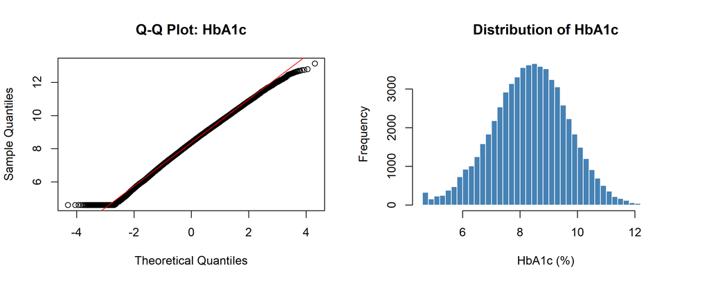

Figure 5: Figure 5. Left: Q-Q plot of HbA1c values. Right: Frequency distribution histogram. A bell-shaped symmetric histogram and points close to the Q-Q diagonal indicate approximate normality.

```r
par(mfrow = c(1, 2))
qqnorm(df$hba1c, main = "Q-Q Plot: HbA1c")
qqline(df$hba1c, col = "red")
hist(df$hba1c, breaks = 50, main = "Distribution of HbA1c",
     xlab = "HbA1c (%)", col = "steelblue", border = "white")
par(mfrow = c(1, 1))
```

> **Note on sample size:** With n = 60,000 observations, the Shapiro-Wilk test is not appropriate, at large n it will always reject H₀ for trivially small, clinically irrelevant deviations from normality. Visual inspection is the appropriate approach. Both LMM and GEE are also robust to mild normality violations at large samples due to the Central Limit Theorem.

## 2.2 Clustering: Intraclass Correlation Coefficient (ICC)

To determine whether the repeated-measures structure requires specialised modelling, an **intercept-only (null) LMM** is fitted. The ICC derived from this model quantifies the proportion of total HbA1c variance attributable to stable between-patient differences.

$$\text{ICC} = \frac{\sigma^2_{\text{between}}}{\sigma^2_{\text{between}} + \sigma^2_{\text{within}}}$$

```r
m_null <- lmer(hba1c ~ 1 + (1 | patient_id), data = df, REML = TRUE)
performance::icc(m_null)
```

| ICC_adjusted | ICC_unadjusted | optional |
| --- | --- | --- |
| 0.8129306 | 0.8129306 | FALSE |

**Result:** ICC = 0.813. This means **81.3%** of the total variance in HbA1c is attributable to stable, persistent differences between patients, only 18.7% represents within-patient change over time. This extremely high ICC confirms that ignoring the repeated-measures structure (i.e., running ordinary MLR on all 60,000 rows) would drastically underestimate standard errors and produce many spurious significant findings. Both LMM and GEE are therefore strongly justified.

## 2.3 Choosing Between LMM and GEE: Complementary Frameworks

**NoteLMM vs GEE: Two Answers to Two Different Questions**

| Feature | LMM | GEE |
| --- | --- | --- |
| **Estimand** | Subject-specific (individual-level) | Population-averaged (marginal) |
| **Research question** | “How does *this patient’s* HbA1c change?” | “What is the expected HbA1c change for a *typical patient*?” |
| **Random effects** | Yes, random intercept ± slope | No, correlation handled via working matrix |
| **Interpretation** | Patient-level trajectory | Population-level policy estimate |
| **Suitable for prediction?** | Yes (individual patients) | No (population only) |
| **Correlation structure** | Implicitly via random effects | Explicitly via working matrix (QIC-selected) |
| **Public health relevance** | Understanding heterogeneity | Programme evaluation & policy |

In this analysis, both methods are applied. LMM provides subject-specific estimates and quantifies the heterogeneity in patient trajectories. GEE provides population-averaged estimates directly interpretable for national T2DM programme evaluation. The two models are complementary, not competing.

## 2.4 GEE-Specific Assumptions

**NoteGEE Has Minimal Formal Assumptions**

Unlike MLR or LMM, GEE does not require normality of the outcome or residuals, nor does it assume a distribution for random effects. The key assumptions for valid GEE inference are:

1. **Correct mean model specification**: the linear predictor correctly captures the relationship between predictors and HbA1c. *Verified via Pearson residual plots in Section 5.*
2. **Independence between clusters**: HbA1c measurements from different patients are independent. *Satisfied by study design.*
3. **Constant variance (Gaussian family)**: appropriate for continuous HbA1c. *Supported by stable residual spread in Section 5.*
4. **Large sample size**: the sandwich variance estimator is asymptotically valid. *Satisfied: n = 20,000 patients.*
5. **MCAR (if missing data present)**: GEE requires data to be Missing Completely At Random. *No missing values in this dataset.*

There is **no assumption** about the correctness of the working correlation structure; the sandwich estimator protects inference regardless of structure choice.

# 3 Linear Mixed Effects Model Analysis

The general LMM formula fitted here is:

$$\text{HbA1c}_{ij} = \underbrace{(\beta_0 + u_{0i})}_{\text{patient-specific intercept}} + \beta_1 \cdot \text{time}_{ij} + \beta_2 \cdot \mathbf{X}_{ij} + \varepsilon_{ij}$$

Where:

- $\beta_0$ = population-average HbA1c intercept
- $u_{0i} \sim N(0, \sigma^2_{\text{between}})$ = patient-specific random intercept deviation
- $\beta_1, \beta_2$ = fixed effects for time and covariates
- $\varepsilon_{ij} \sim N(0, \sigma^2_{\text{within}})$ = within-patient residual

A **model-building strategy** is employed: four progressively richer models are fitted and compared using likelihood ratio tests and AIC. This approach isolates the contribution of each component and justifies the final model choice on statistical grounds.

## 3.1 A: Model Building

### 3.1.1 Null Model (Variance Decomposition)

The null model contains no predictors, only an overall intercept and a random intercept per patient. Its purpose is to decompose total HbA1c variance into between-patient and within-patient components, establishing the baseline ICC.

```r
lmm_null <- lmer(hba1c ~ 1 + (1 | patient_id), data = df, REML = TRUE)
summary(lmm_null)
```

```
Linear mixed model fit by REML. t-tests use Satterthwaite's method [
lmerModLmerTest]
Formula: hba1c ~ 1 + (1 | patient_id)
   Data: df

REML criterion at convergence: 154668.8

Scaled residuals:
     Min       1Q   Median       3Q      Max
-2.98997 -0.31341  0.00276  0.32613  2.88830

Random effects:
 Groups     Name        Variance Std.Dev.
 patient_id (Intercept) 1.3888   1.1785
 Residual               0.3196   0.5653
Number of obs: 60000, groups:  patient_id, 20000

Fixed effects:
             Estimate Std. Error        df t value Pr(>|t|)
(Intercept) 8.342e+00  8.647e-03 2.000e+04   964.8   <2e-16 ***
---
Signif. codes:  0 '***' 0.001 '**' 0.01 '*' 0.05 '.' 0.1 ' ' 1
```

```r
performance::icc(lmm_null)
```

| ICC_adjusted | ICC_unadjusted | optional |
| --- | --- | --- |
| 0.8129306 | 0.8129306 | FALSE |

### 3.1.2 Time-Only Model (Unconditional Growth)

The time-only model adds `time_step` as the sole fixed-effect predictor. This addresses a foundational question: **does HbA1c change significantly over time at all?** The intercept estimates mean HbA1c at T1_Pre; coefficients for T2_Mid and T3_Post represent the change from baseline averaged across all patients.

```r
lmm_time <- lmer(hba1c ~ time_step + (1 | patient_id),
                 data = df, REML = TRUE)
summary(lmm_time)
```

```
Linear mixed model fit by REML. t-tests use Satterthwaite's method [
lmerModLmerTest]
Formula: hba1c ~ time_step + (1 | patient_id)
   Data: df

REML criterion at convergence: 134803.6

Scaled residuals:
     Min       1Q   Median       3Q      Max
-2.94984 -0.43222  0.00097  0.41861  2.82396

Random effects:
 Groups     Name        Variance Std.Dev.
 patient_id (Intercept) 1.4305   1.1960
 Residual               0.1944   0.4409
Number of obs: 60000, groups:  patient_id, 20000

Fixed effects:
                   Estimate Std. Error         df t value Pr(>|t|)
(Intercept)       8.710e+00  9.014e-03  2.353e+04  966.37   <2e-16 ***
time_stepT2_Mid  -3.993e-01  4.409e-03  4.000e+04  -90.55   <2e-16 ***
time_stepT3_Post -7.056e-01  4.409e-03  4.000e+04 -160.02   <2e-16 ***
---
Signif. codes:  0 '***' 0.001 '**' 0.01 '*' 0.05 '.' 0.1 ' ' 1

Correlation of Fixed Effects:
            (Intr) t_T2_M
tm_stpT2_Md -0.245
tm_stpT3_Ps -0.245  0.500
```

**Result:** Both T2_Mid (−0.40%) and T3_Post (−0.71%) show highly significant declines from baseline (both p < 0.0001), confirming a meaningful time trend before accounting for any covariates.

### 3.1.3 Full Fixed-Effects Model

This is the **main adjusted model**, it adds all available covariates alongside time, providing simultaneous estimates of each predictor’s independent association with HbA1c after controlling for all others. `lme4::isSingular()` verifies the model has not been over-parameterised.

```r
lmm_full <- lmer(
  hba1c ~ time_step + age + gender + bmi +
    physical_activity_level + diet_score + sleep_hours +
    medication_adherence + intervention_strength + comorbidity_level +
    (1 | patient_id),
  data = df, REML = TRUE
)

summary(lmm_full)
```

```
Linear mixed model fit by REML. t-tests use Satterthwaite's method [
lmerModLmerTest]
Formula: hba1c ~ time_step + age + gender + bmi + physical_activity_level +
    diet_score + sleep_hours + medication_adherence + intervention_strength +
    comorbidity_level + (1 | patient_id)
   Data: df

REML criterion at convergence: 102015.8

Scaled residuals:
    Min      1Q  Median      3Q     Max
-3.7033 -0.4949 -0.0030  0.4896  4.0874

Random effects:
 Groups     Name        Variance Std.Dev.
 patient_id (Intercept) 1.80592  1.3438
 Residual               0.07721  0.2779
Number of obs: 60000, groups:  patient_id, 20000

Fixed effects:
                                  Estimate Std. Error         df  t value
(Intercept)                      1.066e+01  8.203e-02  2.551e+04  129.977
time_stepT2_Mid                 -2.155e-01  2.974e-03  3.769e+04  -72.483
time_stepT3_Post                -4.205e-01  3.249e-03  4.120e+04 -129.409
age                              1.313e-03  6.505e-04  1.624e+04    2.018
genderMale                      -1.707e-02  1.915e-02  1.624e+04   -0.891
bmi                              8.687e-02  1.780e-03  2.482e+04   48.795
physical_activity_levelModerate -1.945e-01  6.469e-03  4.417e+04  -30.067
physical_activity_levelHigh     -5.155e-01  9.173e-03  4.872e+04  -56.199
diet_score                      -3.205e-01  3.072e-03  5.996e+04 -104.352
sleep_hours                     -4.059e-01  4.818e-03  5.919e+04  -84.234
medication_adherenceModerate    -1.752e-01  7.706e-03  4.499e+04  -22.737
medication_adherenceGood        -3.554e-01  1.010e-02  5.135e+04  -35.177
intervention_strengthStandard   -2.819e-02  2.482e-02  1.625e+04   -1.135
intervention_strengthIntensive  -7.660e-02  2.696e-02  1.630e+04   -2.842
comorbidity_levelMedium          2.386e-02  2.168e-02  1.625e+04    1.100
comorbidity_levelHigh            5.749e-02  2.632e-02  1.628e+04    2.184
                                Pr(>|t|)
(Intercept)                      < 2e-16 ***
time_stepT2_Mid                  < 2e-16 ***
time_stepT3_Post                 < 2e-16 ***
age                              0.04364 *
genderMale                       0.37269
bmi                              < 2e-16 ***
physical_activity_levelModerate  < 2e-16 ***
physical_activity_levelHigh      < 2e-16 ***
diet_score                       < 2e-16 ***
sleep_hours                      < 2e-16 ***
medication_adherenceModerate     < 2e-16 ***
medication_adherenceGood         < 2e-16 ***
intervention_strengthStandard    0.25618
intervention_strengthIntensive   0.00449 **
comorbidity_levelMedium          0.27117
comorbidity_levelHigh            0.02895 *
---
Signif. codes:  0 '***' 0.001 '**' 0.01 '*' 0.05 '.' 0.1 ' ' 1
```

```r
lme4::isSingular(lmm_full)   # check for over-parameterisation
```

```
[1] FALSE
```

### 3.1.4 Random Slope Extension

The random intercept model assumes all patients share the same average rate of change over time. The random slope model relaxes this: `(1 + time_num | patient_id)` allows both the intercept (starting level) and the slope (rate of change) to vary across patients.

```r
lmm_slope <- lmer(
  hba1c ~ time_step + age + gender + bmi +
    physical_activity_level + diet_score + sleep_hours +
    medication_adherence + intervention_strength + comorbidity_level +
    (1 + time_num | patient_id),
  data = df, REML = TRUE
)

lme4::isSingular(lmm_slope)
```

```
[1] FALSE
```

### 3.1.5 Interaction Model: Time × Intervention

This model directly addresses the **primary research question** by testing whether intervention strength groups follow different HbA1c trajectories over time. The `*` operator creates both main effects and all pairwise interaction terms:

`time_step * intervention_strength` expands to: `time_step + intervention_strength + time_step:intervention_strength`

**ImportantCritical Interpretation Rule**

When a statistically significant interaction is present, **main effects must not be interpreted in isolation**. The main effect of `time_step` describes only the Weak group (reference); the main effect of `intervention_strength` describes only T1_Pre (reference). Always use `emmeans()` to obtain properly marginalised cell-level estimates when an interaction is present.

```r
lmm_int <- lmer(
  hba1c ~ time_step * intervention_strength +
    age + gender + bmi + physical_activity_level + diet_score +
    sleep_hours + medication_adherence + comorbidity_level +
    (1 | patient_id),
  data = df, REML = TRUE
)

summary(lmm_int)
```

```
Linear mixed model fit by REML. t-tests use Satterthwaite's method [
lmerModLmerTest]
Formula: hba1c ~ time_step * intervention_strength + age + gender + bmi +
    physical_activity_level + diet_score + sleep_hours + medication_adherence +
    comorbidity_level + (1 | patient_id)
   Data: df

REML criterion at convergence: 101240.2

Scaled residuals:
    Min      1Q  Median      3Q     Max
-3.9055 -0.4954 -0.0013  0.4882  4.1503

Random effects:
 Groups     Name        Variance Std.Dev.
 patient_id (Intercept) 1.77086  1.3307
 Residual               0.07641  0.2764
Number of obs: 60000, groups:  patient_id, 20000

Fixed effects:
                                                  Estimate Std. Error
(Intercept)                                      1.055e+01  8.149e-02
time_stepT2_Mid                                 -1.698e-01  6.011e-03
time_stepT3_Post                                -3.159e-01  6.110e-03
intervention_strengthStandard                    1.209e-02  2.492e-02
intervention_strengthIntensive                   2.158e-02  2.704e-02
age                                              1.323e-03  6.442e-04
genderMale                                      -1.696e-02  1.896e-02
bmi                                              8.443e-02  1.766e-03
physical_activity_levelModerate                 -1.835e-01  6.447e-03
physical_activity_levelHigh                     -4.938e-01  9.158e-03
diet_score                                      -3.120e-01  3.064e-03
sleep_hours                                     -3.957e-01  4.800e-03
medication_adherenceModerate                    -1.617e-01  7.680e-03
medication_adherenceGood                        -3.221e-01  1.013e-02
comorbidity_levelMedium                          2.748e-02  2.147e-02
comorbidity_levelHigh                            6.511e-02  2.607e-02
time_stepT2_Mid:intervention_strengthStandard   -4.288e-02  7.199e-03
time_stepT3_Post:intervention_strengthStandard  -9.225e-02  7.237e-03
time_stepT2_Mid:intervention_strengthIntensive  -1.008e-01  7.914e-03
```

[output cut: 30 more lines]

```
bmi                                             ***
physical_activity_levelModerate                 ***
physical_activity_levelHigh                     ***
diet_score                                      ***
sleep_hours                                     ***
medication_adherenceModerate                    ***
medication_adherenceGood                        ***
comorbidity_levelMedium
comorbidity_levelHigh                           *
time_stepT2_Mid:intervention_strengthStandard   ***
time_stepT3_Post:intervention_strengthStandard  ***
time_stepT2_Mid:intervention_strengthIntensive  ***
time_stepT3_Post:intervention_strengthIntensive ***
---
Signif. codes:  0 '***' 0.001 '**' 0.01 '*' 0.05 '.' 0.1 ' ' 1
```

**Result:** All four interaction terms are highly significant (all p < 0.0001), confirming that intervention groups diverge in their HbA1c trajectories over time. The Intensive group shows the steepest decline.

## 3.2 A: Model Comparison

Formal model comparison determines which of the four models best fits the data. Two complementary approaches are used:

1. **Likelihood Ratio Test (LRT)** via `anova()`: valid for nested models.
2. **AIC (Akaike Information Criterion)**: valid for both nested and non-nested models; lower AIC = better balance of fit and parsimony; a difference > 10 is considered strong evidence.

> **Why refit with REML = FALSE?** REML cannot validly compare models with different fixed-effect structures. ML must be used for fixed-effects comparisons; REML is used only for final parameter estimates.

```r
lmm_null_ml  <- update(lmm_null,  REML = FALSE)
lmm_time_ml  <- update(lmm_time,  REML = FALSE)
lmm_full_ml  <- update(lmm_full,  REML = FALSE)
lmm_int_ml   <- update(lmm_int,   REML = FALSE)

anova(lmm_null_ml, lmm_time_ml, lmm_full_ml)
```

|  | npar | AIC | BIC | logLik | -2*log(L) | Chisq | Df | Pr(>Chisq) |
| --- | --- | --- | --- | --- | --- | --- | --- | --- |
| lmm_null_ml | 3 | 154667.1 | 154694.1 | -77330.55 | 154661.1 | NA | NA | NA |
| lmm_time_ml | 5 | 134787.6 | 134832.7 | -67388.82 | 134777.6 | 19883.45 | 2 | 0 |
| lmm_full_ml | 18 | 101920.2 | 102082.2 | -50942.10 | 101884.2 | 32893.43 | 13 | 0 |

```r
AIC(lmm_null_ml, lmm_time_ml, lmm_full_ml, lmm_int_ml)
```

|  | df | AIC |
| --- | --- | --- |
| lmm_null_ml | 3 | 154667.1 |
| lmm_time_ml | 5 | 134787.6 |
| lmm_full_ml | 18 | 101920.2 |
| lmm_int_ml | 22 | 101119.0 |

| Model | AIC | Improvement |
| --- | --- | --- |
| Null | 154,667 | Baseline, no predictors |
| Time-only | 134,788 | −19,879; time highly significant |
| Full covariates | 101,920 | −32,868; covariates essential |
| Interaction | **101,119** | −801; interaction significant |

## 3.3 A: Model Assessment

### 3.3.1 Variance Explained: Marginal and Conditional R²

LMMs have two R² values (Nakagawa & Schielzeth, 2013):

- **R²m (marginal)** = proportion of total variance explained by fixed effects only
- **R²c (conditional)** = proportion explained by fixed + random effects combined

A large gap between R²m and R²c confirms the random intercept is absorbing substantial between-patient variance, validating the LMM approach.

```r
MuMIn::r.squaredGLMM(lmm_full)
```

```
           R2m       R2c
[1,] 0.3677706 0.9740781
```

```r
performance::r2(lmm_full)
```

```
# R2 for Mixed Models

  Conditional R2: 0.974
     Marginal R2: 0.368
```

```r
performance::icc(lmm_full)
```

| ICC_adjusted | ICC_unadjusted | optional |
| --- | --- | --- |
| 0.9589993 | 0.6063076 | FALSE |

**Results:** R²m = 0.368, R²c = 0.974. Fixed effects alone explain 36.8% of variance; once patient-level random intercepts are included, 97.4% is explained. The gap (~60%) represents stable between-patient differences that the measured covariates cannot fully capture, confirming LMM is strongly justified.

### 3.3.2 Residual Diagnostics

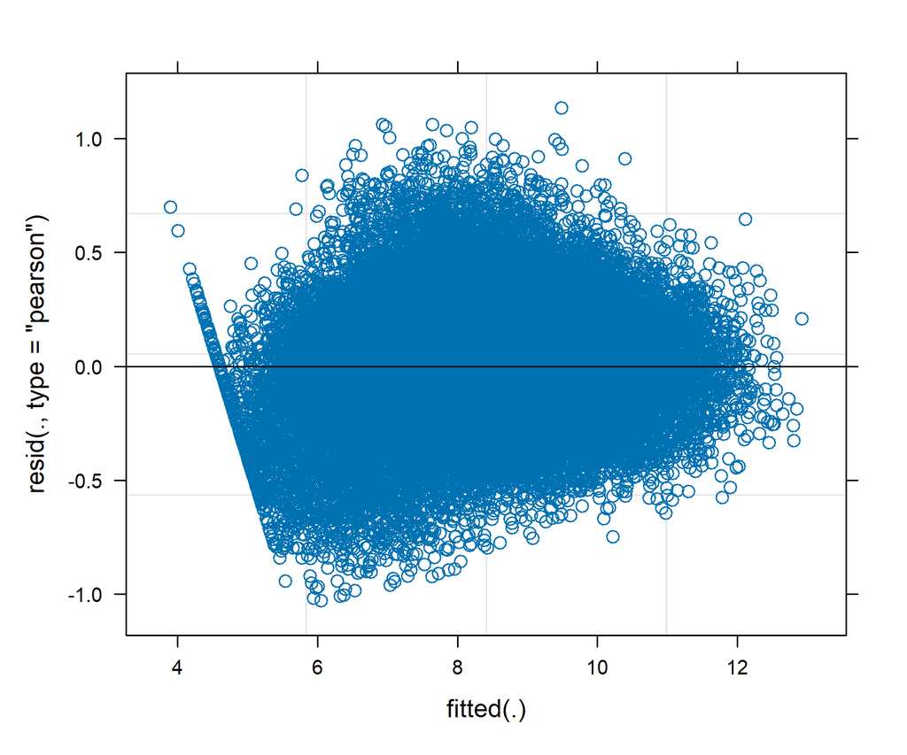

```r
plot(lmm_full)                                    # residuals vs fitted
```

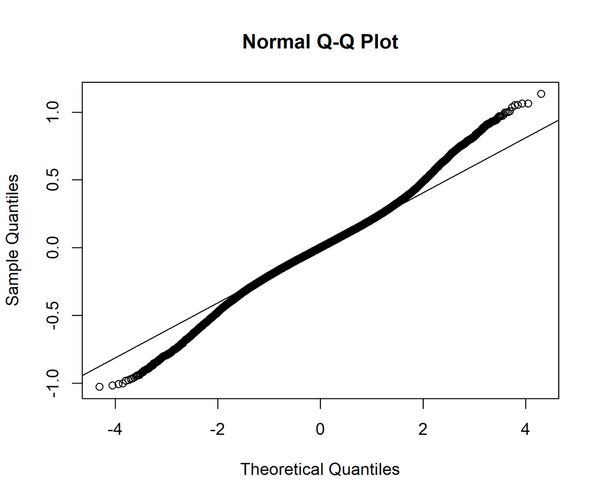

```r
qqnorm(resid(lmm_full)); qqline(resid(lmm_full))  # normality of residuals
```

## 3.4 A: Results: Estimated Marginal Means & Contrasts

### 3.4.1 Within-Group Time Contrasts

When a significant interaction is present, `emmeans()` calculates model-predicted mean HbA1c at each cell of the time × intervention grid, **marginalised over** all other covariates. `contrast()` then performs all pairwise comparisons within each intervention group across time, with Bonferroni correction.

```r
emm_int <- emmeans::emmeans(lmm_int, ~ time_step | intervention_strength)
emm_int
```

```
intervention_strength = Weak:
 time_step emmean     SE  df asymp.LCL asymp.UCL
 T1_Pre     8.554 0.0210 Inf     8.513     8.595
 T2_Mid     8.384 0.0209 Inf     8.343     8.425
 T3_Post    8.238 0.0209 Inf     8.197     8.279

intervention_strength = Standard:
 time_step emmean     SE  df asymp.LCL asymp.UCL
 T1_Pre     8.566 0.0143 Inf     8.538     8.594
 T2_Mid     8.354 0.0142 Inf     8.326     8.381
 T3_Post    8.158 0.0142 Inf     8.130     8.186

intervention_strength = Intensive:
 time_step emmean     SE  df asymp.LCL asymp.UCL
 T1_Pre     8.576 0.0177 Inf     8.541     8.610
 T2_Mid     8.305 0.0177 Inf     8.270     8.340
 T3_Post    8.036 0.0178 Inf     8.001     8.071

Results are averaged over the levels of: gender, physical_activity_level, medication_adherence, comorbidity_level
Degrees-of-freedom method: asymptotic
Confidence level used: 0.95
```

```r
emmeans::contrast(emm_int, method = "pairwise", adjust = "bonferroni")
```

```
intervention_strength = Weak:
 contrast         estimate      SE  df z.ratio p.value
 T1_Pre - T2_Mid     0.170 0.00601 Inf  28.246 <0.0001
 T1_Pre - T3_Post    0.316 0.00611 Inf  51.704 <0.0001
 T2_Mid - T3_Post    0.146 0.00598 Inf  24.443 <0.0001

intervention_strength = Standard:
 contrast         estimate      SE  df z.ratio p.value
 T1_Pre - T2_Mid     0.213 0.00413 Inf  51.546 <0.0001
 T1_Pre - T3_Post    0.408 0.00431 Inf  94.614 <0.0001
 T2_Mid - T3_Post    0.196 0.00405 Inf  48.259 <0.0001

intervention_strength = Intensive:
 contrast         estimate      SE  df z.ratio p.value
 T1_Pre - T2_Mid     0.271 0.00525 Inf  51.570 <0.0001
 T1_Pre - T3_Post    0.539 0.00556 Inf  97.003 <0.0001
 T2_Mid - T3_Post    0.269 0.00510 Inf  52.742 <0.0001

Results are averaged over the levels of: gender, physical_activity_level, medication_adherence, comorbidity_level
Degrees-of-freedom method: asymptotic
P value adjustment: bonferroni method for 3 tests
```

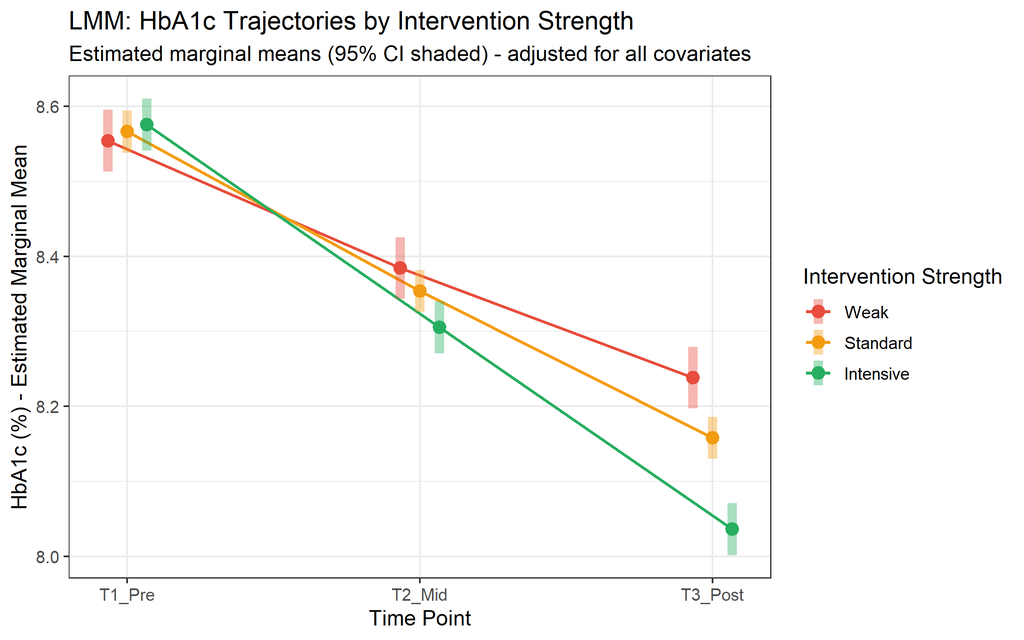

Figure 6: Figure 7. Estimated marginal mean HbA1c trajectories by intervention strength from the LMM interaction model (95% CI shaded). Non-parallel lines confirm a significant Time × Intervention interaction.

```r
emmeans::emmip(lmm_int, intervention_strength ~ time_step, CIs = TRUE) +
  scale_colour_manual(values = c("Weak"      = "#e74c3c",
                                 "Standard"  = "#f39c12",
                                 "Intensive" = "#27ae60")) +
  labs(
    title    = "LMM: HbA1c Trajectories by Intervention Strength",
    subtitle = "Estimated marginal means (95% CI shaded) - adjusted for all covariates",
    x        = "Time Point",
    y        = "HbA1c (%) - Estimated Marginal Mean",
    colour   = "Intervention Strength"
  ) +
  theme_bw(base_size = 12)
```

### 3.4.2 Between-Group Contrasts at Endpoint (T3_Post)

This block answers the complementary question: **At the study endpoint, do the three intervention groups differ significantly from each other?** Bonferroni correction is applied across the three pairwise contrasts.

```r
emm_t3 <- emmeans::emmeans(lmm_int, ~ intervention_strength | time_step,
                            at = list(time_step = "T3_Post"))
emm_t3
```

```
time_step = T3_Post:
 intervention_strength emmean     SE  df asymp.LCL asymp.UCL
 Weak                   8.238 0.0209 Inf     8.197     8.279
 Standard               8.158 0.0142 Inf     8.130     8.186
 Intensive              8.036 0.0178 Inf     8.001     8.071

Results are averaged over the levels of: gender, physical_activity_level, medication_adherence, comorbidity_level
Degrees-of-freedom method: asymptotic
Confidence level used: 0.95
```

```r
emmeans::contrast(emm_t3, method = "pairwise", adjust = "bonferroni")
```

```
time_step = T3_Post:
 contrast             estimate     SE  df z.ratio p.value
 Weak - Standard        0.0802 0.0249 Inf   3.214  0.0039
 Weak - Intensive       0.2019 0.0271 Inf   7.442 <0.0001
 Standard - Intensive   0.1218 0.0223 Inf   5.462 <0.0001

Results are averaged over the levels of: gender, physical_activity_level, medication_adherence, comorbidity_level
Degrees-of-freedom method: asymptotic
P value adjustment: bonferroni method for 3 tests
```

At T3_Post, the estimated marginal HbA1c means are:

- **Weak**: 8.238% (95% CI: 8.197–8.279)
- **Standard**: 8.158% (95% CI: 8.130–8.186)
- **Intensive**: 8.036% (95% CI: 8.001–8.071)

All three pairwise comparisons are statistically significant after Bonferroni correction. Intensive intervention achieves HbA1c 0.202% lower than Weak (p < 0.0001) and 0.122% lower than Standard (p < 0.0001). Even Standard confers a significant advantage over Weak (p = 0.0039), confirming a dose–response gradient across all three tiers at the study endpoint.

## 3.5 P: Final Results: Model Table & Forest Plot

### 3.5.1 Final LMM Model Table

The table below is the primary results table for the LMM analysis, reporting fixed-effect estimates from the best-fitting model (`lmm_int`) with 95% confidence intervals, p-values, random-effect variance components, ICC, R²m, R²c, and AIC.

```r
sjPlot::tab_model(
  lmm_int,
  show.re.var = TRUE,
  show.icc    = TRUE,
  show.r2     = TRUE,
  show.aic    = TRUE,
  pred.labels = c(
    "(Intercept)",
    "Time: T2_Mid",
    "Time: T3_Post",
    "Intervention: Standard",
    "Intervention: Intensive",
    "Age",
    "Gender: Male",
    "BMI",
    "Physical Activity: Moderate",
    "Physical Activity: High",
    "Diet Score",
    "Sleep Hours",
    "Medication Adherence: Moderate",
    "Medication Adherence: Good",
    "Comorbidity: Medium",
    "Comorbidity: High",
    "T2_Mid × Standard",
    "T3_Post × Standard",
    "T2_Mid × Intensive",
    "T3_Post × Intensive"
  ),
  title = "Table 3: LMM Interaction Model - Predictors of HbA1c (n = 60,000 observations; 20,000 patients)"
)
```

Table 3: LMM Interaction Model - Predictors of HbA1c (n = 60,000 observations; 20,000 patients)

|  | hba 1 c |  |  |
| --- | --- | --- | --- |
| Predictors | Estimates | CI | p |
| (Intercept) | 10.55 | 10.39 – 10.71 | **<0.001** |
| Time: T2_Mid | -0.17 | -0.18 – -0.16 | **<0.001** |
| Time: T3_Post | -0.32 | -0.33 – -0.30 | **<0.001** |
| Intervention: Standard | 0.01 | -0.04 – 0.06 | 0.628 |
| Intervention: Intensive | 0.02 | -0.03 – 0.07 | 0.425 |
| Age | 0.00 | 0.00 – 0.00 | **0.040** |
| Gender: Male | -0.02 | -0.05 – 0.02 | 0.371 |
| BMI | 0.08 | 0.08 – 0.09 | **<0.001** |
| Physical Activity: Moderate | -0.18 | -0.20 – -0.17 | **<0.001** |
| Physical Activity: High | -0.49 | -0.51 – -0.48 | **<0.001** |
| Diet Score | -0.31 | -0.32 – -0.31 | **<0.001** |
| Sleep Hours | -0.40 | -0.41 – -0.39 | **<0.001** |
| Medication Adherence: Moderate | -0.16 | -0.18 – -0.15 | **<0.001** |
| Medication Adherence: Good | -0.32 | -0.34 – -0.30 | **<0.001** |
| Comorbidity: Medium | 0.03 | -0.01 – 0.07 | 0.201 |
| Comorbidity: High | 0.07 | 0.01 – 0.12 | **0.012** |
| T2_Mid × Standard | -0.04 | -0.06 – -0.03 | **<0.001** |
| T3_Post × Standard | -0.09 | -0.11 – -0.08 | **<0.001** |
| T2_Mid × Intensive | -0.10 | -0.12 – -0.09 | **<0.001** |
| T3_Post × Intensive | -0.22 | -0.24 – -0.21 | **<0.001** |
| Random Effects |  |  |  |
| σ<sup>2</sup> | 0.08 |  |  |
| τ<sub>00</sub> <sub>patient_id</sub> | 1.77 |  |  |
| ICC | 0.96 |  |  |
| N <sub>patient_id</sub> | 20000 |  |  |
| Observations | 60000 |  |  |
| Marginal R<sup>2</sup> / Conditional R<sup>2</sup> | 0.360 / 0.974 |  |  |
| AIC | 101284.157 |  |  |

### 3.5.2 Forest Plot: Fixed Effects

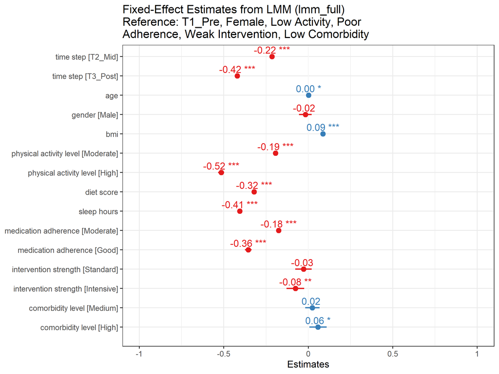

Figure 7: Figure 8. Forest plot of fixed-effect estimates from lmm_full (95% CI). Points left of the dashed zero line (red) indicate HbA1c-lowering effects; points to the right indicate HbA1c-raising effects. Intervals crossing zero indicate non-significant predictors.

```r
sjPlot::plot_model(
  lmm_full,
  type         = "est",
  show.values  = TRUE,
  show.p       = TRUE,
  value.offset = 0.35,
  title = "Fixed-Effect Estimates from LMM (lmm_full)\nReference: T1_Pre, Female, Low Activity, Poor Adherence, Weak Intervention, Low Comorbidity"
) +
  theme_bw(base_size = 11) +
  geom_vline(xintercept = 0, linetype = "dashed", colour = "grey40")
```

### 3.5.3 Model Fit Summary

```r
r2_lmm  <- MuMIn::r.squaredGLMM(lmm_full)
lmm_r2m <- r2_lmm[1, "R2m"]
lmm_r2c <- r2_lmm[1, "R2c"]
icc_val <- as.numeric(performance::icc(lmm_null)$ICC_adjusted)
```

| Metric | Value | Interpretation |
| --- | --- | --- |
| ICC (null model) | 0.813 | 81.3% of HbA1c variance is between patients: LMM required |
| R²m (marginal) | 0.368 | Fixed effects explain 36.8% of total variance |
| R²c (conditional) | 0.974 | Fixed + random effects explain 97.4% of total variance |
| AIC (lmm_int) | 101,119 | Best-fitting model across all four candidates |

## 3.6 LMM Conclusions

This analysis examined longitudinal HbA1c trajectories in 20,000 patients across three time points using LMM. The null model ICC of **0.813** confirmed that 81.3% of total HbA1c variance is attributable to stable between-patient differences, validating the LMM framework.

All four time × intervention interaction terms were statistically significant (all p < 0.0001). The Intensive intervention produced the steepest HbA1c decline (mean 8.04% at T3_Post vs 8.24% for Weak). The key independent modifiable predictors were: physical activity High (−0.52%*), sleep hours (−0.41%*), medication adherence Good (−0.36%*), and diet score (−0.32%*). BMI (+0.09%***) was the most important detrimental factor. At T3_Post, all three intervention groups differed significantly from each other after Bonferroni correction.

# 4 Generalised Estimating Equations Analysis

Whereas LMM estimates subject-specific effects, GEE estimates **population-averaged (marginal) effects**, the expected HbA1c change for a typical patient drawn from the T2DM population. These coefficients directly answer policy-relevant questions: “If all Malaysian T2DM patients received Intensive versus Weak intervention, what is the expected population-level HbA1c difference?” The GEE estimand is therefore the appropriate primary method for public health programme evaluation.

## 4.1 GEE Theoretical Framework

### 4.1.1 The Marginal (Population-Averaged) Model

GEE estimates the **population-averaged** expectation of HbA1c. For a continuous outcome with an identity link:

$$\begin{aligned}
E(Y_{ij} \mid \mathbf{X}_{ij}) = \; &\beta_0
+ \beta_1 \, \text{T2 Mid}_{ij} + \beta_2 \, \text{T3 Post}_{ij} \\
&+ \beta_3 \, \text{Standard}_{ij} + \beta_4 \, \text{Intensive}_{ij} \\
&+ \beta_5 \, \text{Age}_{ij} + \beta_6 \, \text{Male}_{ij} + \beta_7 \, \text{BMI}_{ij} \\
&+ \beta_8 \, \text{PA Moderate}_{ij} + \beta_9 \, \text{PA High}_{ij} \\
&+ \beta_{10} \, \text{Diet Score}_{ij} + \beta_{11} \, \text{Sleep Hours}_{ij} \\
&+ \beta_{12} \, \text{MedAdh Moderate}_{ij} + \beta_{13} \, \text{MedAdh Good}_{ij} \\
&+ \beta_{14} \, \text{Comorbidity Medium}_{ij} + \beta_{15} \, \text{Comorbidity High}_{ij}
\end{aligned}$$

Each $\beta$ coefficient represents the **expected change in HbA1c (%)** across the entire T2DM population for a one-unit change in the predictor, holding all other variables constant.

### 4.1.2 Working Correlation Structures

Four structures were fitted and compared using QIC. The working correlation matrix $\mathbf{R}_i(\alpha)$ defines the assumed within-patient correlation pattern:

| Structure | `corstr =` | Assumption | Role |
| --- | --- | --- | --- |
| Independence | `"independence"` | All off-diagonal = 0 | Baseline reference |
| Exchangeable | `"exchangeable"` | All pairs = $\alpha$ | Primary candidate |
| AR(1) | `"ar1"` | Correlation decays: $\alpha^{\|j-k\|}$ | Sensitivity check |
| Unstructured | `"unstructured"` | Each pair has its own $\alpha_{jk}$ | Flexible benchmark |

### 4.1.3 QIC Model Selection Criterion

The **Quasi-likelihood under Independence Criterion** (Pan, 2001) is the GEE analogue of AIC. Lower QIC indicates a better-fitting correlation structure.

$$\text{QIC} = -2\,\hat{Q}(\hat{\boldsymbol{\beta}}) + 2\,\text{tr}(\hat{\boldsymbol{\Omega}}_I \hat{\mathbf{V}}_R)$$

The first term ($-2\hat{Q}$) measures goodness of fit; the second term ($2\text{tr}(\hat{\boldsymbol{\Omega}}_I \hat{\mathbf{V}}_R)$) penalises for complexity. A more complex structure (e.g., Unstructured with 3 free $\alpha$ parameters) must improve fit substantially to overcome this penalty.

### 4.1.4 Robustness: The Sandwich Variance Estimator

A critical property of GEE is that **valid estimates and correct standard errors are obtained even if the working correlation structure is misspecified**, provided the robust sandwich variance estimator is used (Liang & Zeger, 1986). This means β estimates remain consistent and standard errors are corrected using observed residuals, not model assumptions. QIC guides the best-fitting structure, but inference is protected even if the chosen structure is imperfect.

## 4.2 A: Univariate GEE Screening

Univariate GEE with Exchangeable working correlation screens each predictor individually. Variables with p < 0.25 are retained for multivariable modelling.

```r
library(purrr)

predictors <- c(
  "time_step", "intervention_strength",
  "age", "gender", "bmi",
  "physical_activity_level", "diet_score",
  "sleep_hours", "medication_adherence",
  "comorbidity_level"
)

uni_list <- map(predictors, function(pred) {
  fml <- as.formula(paste("hba1c ~", pred))
  geeglm(
    fml,
    id     = patient_id,
    data   = df,
    family = gaussian(link = "identity"),
    corstr = "exchangeable"
  )
})

names(uni_list) <- predictors

uni_results <- map_dfr(names(uni_list), function(pred) {
  broom::tidy(uni_list[[pred]], conf.int = TRUE) |>
    filter(term != "(Intercept)") |>
    mutate(predictor = pred)
}) |>
  mutate(
    Predictor = case_match(term,
      "time_stepT2_Mid"                      ~ "Time: T2_Mid vs T1_Pre",
      "time_stepT3_Post"                     ~ "Time: T3_Post vs T1_Pre",
      "intervention_strengthStandard"        ~ "Intervention: Standard vs Weak",
      "intervention_strengthIntensive"       ~ "Intervention: Intensive vs Weak",
      "age"                                  ~ "Age (years)",
      "genderMale"                           ~ "Gender: Male vs Female",
      "bmi"                                  ~ "BMI (kg/m²)",
      "physical_activity_levelModerate"      ~ "Physical Activity: Moderate vs Low",
      "physical_activity_levelHigh"          ~ "Physical Activity: High vs Low",
      "diet_score"                           ~ "Diet Score",
      "sleep_hours"                          ~ "Sleep Hours",
      "medication_adherenceModerate"         ~ "Medication Adherence: Moderate vs Poor",
      "medication_adherenceGood"             ~ "Medication Adherence: Good vs Poor",
      "comorbidity_levelMedium"              ~ "Comorbidity: Medium vs Low",
      "comorbidity_levelHigh"                ~ "Comorbidity: High vs Low",
      .default                               = term
    ),
    `Crude β (95% CI)` = sprintf("%.3f (%.3f, %.3f)",
                                  estimate, conf.low, conf.high),
    `p-value` = case_when(
      p.value < 0.001 ~ "< 0.001***",
      p.value < 0.01  ~ sprintf("%.3f**", p.value),
      p.value < 0.05  ~ sprintf("%.3f*",  p.value),
      TRUE            ~ sprintf("%.3f",    p.value)
    ),
    Significant = ifelse(p.value < 0.05, "✓", "")
  ) |>
  select(Predictor, `Crude β (95% CI)`,
         `Robust SE` = std.error, `p-value`, Significant)
```

```r
knitr::kable(
  uni_results,
  digits  = 3,
  caption = "Table 4. Univariate GEE Associations with HbA1c (%) (Exchangeable Working Correlation)"
) |>
  kable_styling(
    bootstrap_options = c("striped", "hover", "condensed"),
    full_width        = FALSE
  ) |>
  pack_rows("Time Effects",          1, 2)  |>
  pack_rows("Intervention Effects",  3, 4)  |>
  pack_rows("Socio-demographic",     5, 7)  |>
  pack_rows("Lifestyle Factors",     8, 11) |>
  pack_rows("Clinical Factors",     12, 15) |>
  column_spec(3, bold = TRUE, color = "#009E73") |>
  footnote(general = c(
    "Crude β = unadjusted population-averaged change in HbA1c (%) per unit change in predictor.",
    "Each row is from a separate GEE model with only that predictor (simple GEE).",
    "Exchangeable working correlation; robust sandwich variance estimator.",
    "Reference categories: time_step = T1_Pre; intervention = Weak; gender = Female;",
    "  physical_activity = Low; medication_adherence = Poor; comorbidity = Low.",
    "✓ = significant at p < 0.05.",
    "* p < 0.05   ** p < 0.01   *** p < 0.001"
  ))
```

Table 4. Univariate GEE Associations with HbA1c (%) (Exchangeable Working Correlation)

| Predictor | Crude β (95% CI) | Robust SE | p-value | Significant |
| --- | --- | --- | --- | --- |
| **Time Effects** |  |  |  |  |
| Time: T2_Mid vs T1_Pre | -0.399 (-0.406, -0.392) | 0.004 | < 0.001*** | ✓ |
| Time: T3_Post vs T1_Pre | -0.706 (-0.718, -0.694) | 0.006 | < 0.001*** | ✓ |
| **Intervention Effects** |  |  |  |  |
| Intervention: Standard vs Weak | -0.150 (-0.193, -0.107) | 0.022 | < 0.001*** | ✓ |
| Intervention: Intensive vs Weak | -0.350 (-0.397, -0.304) | 0.024 | < 0.001*** | ✓ |
| **Socio-demographic** |  |  |  |  |
| Age (years) | 0.002 (0.000, 0.003) | 0.001 | 0.007** | ✓ |
| Gender: Male vs Female | -0.002 (-0.036, 0.032) | 0.017 | 0.918 |  |
| BMI (kg/m²) | 0.118 (0.114, 0.122) | 0.002 | < 0.001*** | ✓ |
| **Lifestyle Factors** |  |  |  |  |
| Physical Activity: Moderate vs Low | -0.325 (-0.345, -0.306) | 0.010 | < 0.001*** | ✓ |
| Physical Activity: High vs Low | -1.279 (-1.307, -1.251) | 0.014 | < 0.001*** | ✓ |
| Diet Score | -0.641 (-0.649, -0.632) | 0.004 | < 0.001*** | ✓ |
| Sleep Hours | -0.732 (-0.747, -0.716) | 0.008 | < 0.001*** | ✓ |
| **Clinical Factors** |  |  |  |  |
| Medication Adherence: Moderate vs Poor | -0.085 (-0.101, -0.069) | 0.008 | < 0.001*** | ✓ |
| Medication Adherence: Good vs Poor | -0.780 (-0.806, -0.754) | 0.013 | < 0.001*** | ✓ |
| Comorbidity: Medium vs Low | 0.124 (0.085, 0.163) | 0.020 | < 0.001*** | ✓ |
| Comorbidity: High vs Low | 0.270 (0.224, 0.315) | 0.023 | < 0.001*** | ✓ |

Note:  
Crude β = unadjusted population-averaged change in HbA1c (%) per unit change in predictor.  
Each row is from a separate GEE model with only that predictor (simple GEE).  
Exchangeable working correlation; robust sandwich variance estimator.  
Reference categories: time_step = T1_Pre; intervention = Weak; gender = Female;  
physical_activity = Low; medication_adherence = Poor; comorbidity = Low.  
✓ = significant at p < 0.05.  
* p < 0.05 ** p < 0.01 *** p < 0.001

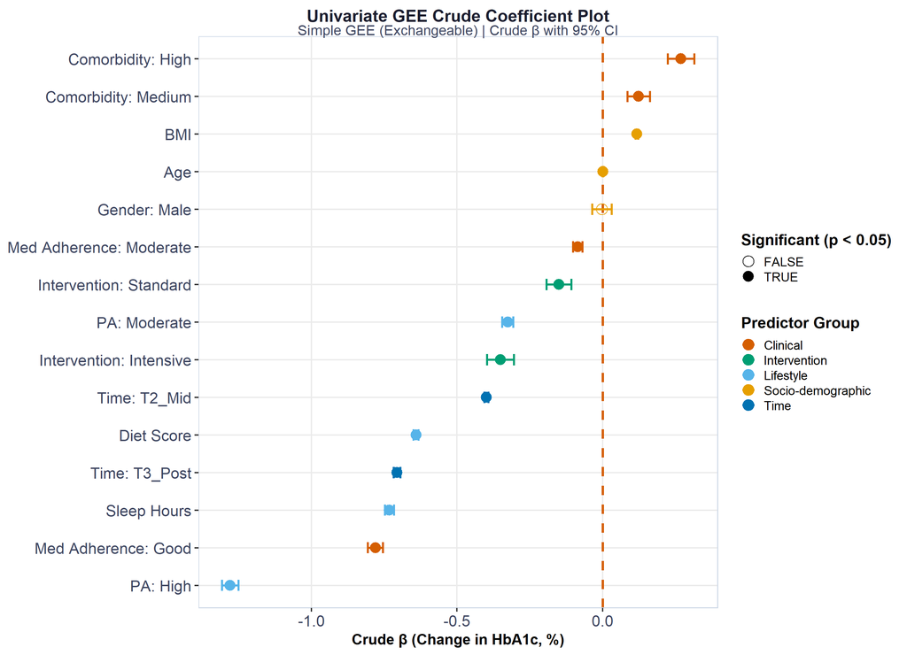

Figure 8: Figure 9. Univariate GEE crude coefficient plot. Filled circles = significant (p < 0.05); open circles = non-significant. Gender (Male) is the only non-significant predictor; all others proceed to multivariable adjustment.

```r
uni_plot <- map_dfr(names(uni_list), function(pred) {
  broom::tidy(uni_list[[pred]], conf.int = TRUE) |>
    filter(term != "(Intercept)") |>
    mutate(predictor = pred)
}) |>
  mutate(
    label = case_match(term,
      "time_stepT2_Mid"                      ~ "Time: T2_Mid",
      "time_stepT3_Post"                     ~ "Time: T3_Post",
      "intervention_strengthStandard"        ~ "Intervention: Standard",
      "intervention_strengthIntensive"       ~ "Intervention: Intensive",
      "age"                                  ~ "Age",
      "genderMale"                           ~ "Gender: Male",
      "bmi"                                  ~ "BMI",
      "physical_activity_levelModerate"      ~ "PA: Moderate",
      "physical_activity_levelHigh"          ~ "PA: High",
      "diet_score"                           ~ "Diet Score",
      "sleep_hours"                          ~ "Sleep Hours",
      "medication_adherenceModerate"         ~ "Med Adherence: Moderate",
      "medication_adherenceGood"             ~ "Med Adherence: Good",
      "comorbidity_levelMedium"              ~ "Comorbidity: Medium",
      "comorbidity_levelHigh"                ~ "Comorbidity: High",
      .default                               = term
    ),
    group = case_when(
      str_detect(term, "time_step")              ~ "Time",
      str_detect(term, "intervention_strength")  ~ "Intervention",
      term %in% c("age", "genderMale", "bmi")    ~ "Socio-demographic",
      str_detect(term, "physical_activity|diet|sleep") ~ "Lifestyle",
      str_detect(term, "medication|comorbidity") ~ "Clinical"
    ),
    significant = p.value < 0.05
  )

group_colours <- c(
  "Time"              = "#0072B2",
  "Intervention"      = "#009E73",
  "Socio-demographic" = "#E69F00",
  "Lifestyle"         = "#56B4E9",
  "Clinical"          = "#D55E00"
)

ggplot(uni_plot,
       aes(x = estimate, y = reorder(label, estimate),
           colour = group, shape = significant)) +
  geom_vline(xintercept = 0, linetype = "dashed",
             colour = "#D55E00", linewidth = 0.8) +
  geom_errorbarh(aes(xmin = conf.low, xmax = conf.high),
                 height = 0.3, linewidth = 0.7) +
  geom_point(size = 3.5) +
  scale_colour_manual(values = group_colours, name = "Predictor Group") +
  scale_shape_manual(values = c("TRUE" = 16, "FALSE" = 1),
                     name   = "Significant (p < 0.05)") +
  labs(
    title    = "Univariate GEE Crude Coefficient Plot",
    subtitle = "Simple GEE (Exchangeable) | Crude β with 95% CI",
    x        = "Crude β (Change in HbA1c, %)",
    y        = NULL
  ) +
  theme_gee(base_size = 11) +
  theme(legend.position = "right")
```

**TipFigure 9 Interpretation**

## 4.3 A: Multivariable GEE: Four Correlation Structures

Four multivariable GEE models are fitted simultaneously, each containing all predictors but with a different working correlation structure. All predictors identified in univariate screening are retained, including Gender, given its established role as a biological confounder.

```r
gee_ind <- geeglm(
  hba1c ~ time_step + intervention_strength +
           age + gender + bmi +
           physical_activity_level + diet_score +
           sleep_hours + medication_adherence +
           comorbidity_level,
  id     = patient_id,
  data   = df,
  family = gaussian(link = "identity"),
  corstr = "independence"
)

gee_exch <- geeglm(
  hba1c ~ time_step + intervention_strength +
           age + gender + bmi +
           physical_activity_level + diet_score +
           sleep_hours + medication_adherence +
           comorbidity_level,
  id     = patient_id,
  data   = df,
  family = gaussian(link = "identity"),
  corstr = "exchangeable"
)

gee_ar1 <- geeglm(
  hba1c ~ time_step + intervention_strength +
           age + gender + bmi +
           physical_activity_level + diet_score +
           sleep_hours + medication_adherence +
           comorbidity_level,
  id     = patient_id,
  data   = df,
  family = gaussian(link = "identity"),
  corstr = "ar1"
)

gee_unstr <- geeglm(
  hba1c ~ time_step + intervention_strength +
           age + gender + bmi +
           physical_activity_level + diet_score +
           sleep_hours + medication_adherence +
           comorbidity_level,
  id     = patient_id,
  data   = df,
  family = gaussian(link = "identity"),
  corstr = "unstructured"
)

cat("All four GEE models fitted successfully.\n")
```

```
All four GEE models fitted successfully.
```

```r
cat(sprintf("Unstructured α parameters: α12=%.4f  α13=%.4f  α23=%.4f\n",
            gee_unstr$geese$alpha[1],
            gee_unstr$geese$alpha[2],
            gee_unstr$geese$alpha[3]))
```

```
Unstructured α parameters: α12=0.9399  α13=0.9092  α23=0.9774
```

The raw summaries for each structure are presented below. These allow comparison of point estimates under different correlation assumptions before formal QIC-based selection in the next section. Inference should not be drawn from any single summary here; the QIC-selected model is the basis for final inference.

### 4.3.1 Independence (Baseline Reference)

```r
summary(gee_ind)
```

```
Call:
geeglm(formula = hba1c ~ time_step + intervention_strength +
    age + gender + bmi + physical_activity_level + diet_score +
    sleep_hours + medication_adherence + comorbidity_level, family = gaussian(link = "identity"),
    data = df, id = patient_id, corstr = "independence")

 Coefficients:
                                  Estimate    Std.err      Wald Pr(>|W|)
(Intercept)                      9.8100519  0.0854323 13185.540  < 2e-16 ***
time_stepT2_Mid                 -0.3182076  0.0037667  7136.631  < 2e-16 ***
time_stepT3_Post                -0.6044971  0.0060004 10149.266  < 2e-16 ***
intervention_strengthStandard   -0.0863413  0.0210554    16.816 4.12e-05 ***
intervention_strengthIntensive  -0.2142895  0.0228679    87.811  < 2e-16 ***
age                              0.0014949  0.0005492     7.410  0.00649 **
genderMale                      -0.0047736  0.0162293     0.087  0.76865
bmi                              0.0108851  0.0016768    42.142 8.49e-11 ***
physical_activity_levelModerate -0.1662461  0.0174869    90.381  < 2e-16 ***
physical_activity_levelHigh     -0.5299379  0.0201244   693.430  < 2e-16 ***
diet_score                      -0.0664025  0.0045412   213.813  < 2e-16 ***
sleep_hours                     -0.1041436  0.0077634   179.954  < 2e-16 ***
medication_adherenceModerate    -0.1431315  0.0202176    50.120 1.45e-12 ***
medication_adherenceGood        -0.5273662  0.0198546   705.508  < 2e-16 ***
comorbidity_levelMedium          0.0778810  0.0184891    17.743 2.53e-05 ***
comorbidity_levelHigh            0.1662408  0.0222979    55.584 8.96e-14 ***
---
Signif. codes:  0 '***' 0.001 '**' 0.01 '*' 0.05 '.' 0.1 ' ' 1

Correlation structure = independence
Estimated Scale Parameters:

            Estimate Std.err
(Intercept)    1.405 0.01284
Number of clusters:   20000  Maximum cluster size: 3
```

**NoteIndependence Model Note**

Independence GEE is equivalent to OLS regression with robust sandwich SE. It ignores within-patient correlation entirely, presented here as the formal baseline against which correlated structures are compared.

### 4.3.2 Exchangeable

```r
summary(gee_exch)
```

```
Call:
geeglm(formula = hba1c ~ time_step + intervention_strength +
    age + gender + bmi + physical_activity_level + diet_score +
    sleep_hours + medication_adherence + comorbidity_level, family = gaussian(link = "identity"),
    data = df, id = patient_id, corstr = "exchangeable")

 Coefficients:
                                 Estimate   Std.err     Wald Pr(>|W|)
(Intercept)                     10.662525  0.084291 16001.30   <2e-16 ***
time_stepT2_Mid                 -0.215550  0.002357  8361.10   <2e-16 ***
time_stepT3_Post                -0.420470  0.003337 15874.43   <2e-16 ***
intervention_strengthStandard   -0.028192  0.024982     1.27   0.2591
intervention_strengthIntensive  -0.076615  0.027081     8.00   0.0047 **
age                              0.001313  0.000648     4.10   0.0430 *
genderMale                      -0.017066  0.019131     0.80   0.3723
bmi                              0.086852  0.001905  2078.02   <2e-16 ***
physical_activity_levelModerate -0.194503  0.006249   968.73   <2e-16 ***
physical_activity_levelHigh     -0.515520  0.010060  2625.89   <2e-16 ***
diet_score                      -0.320496  0.003417  8795.44   <2e-16 ***
sleep_hours                     -0.405862  0.005133  6252.87   <2e-16 ***
medication_adherenceModerate    -0.175213  0.006411   746.86   <2e-16 ***
medication_adherenceGood        -0.355396  0.009841  1304.10   <2e-16 ***
comorbidity_levelMedium          0.023863  0.021718     1.21   0.2719
comorbidity_levelHigh            0.057496  0.026192     4.82   0.0282 *
---
Signif. codes:  0 '***' 0.001 '**' 0.01 '*' 0.05 '.' 0.1 ' ' 1

Correlation structure = exchangeable
Estimated Scale Parameters:

            Estimate Std.err
(Intercept)     1.88  0.0171
  Link = identity

Estimated Correlation Parameters:
      Estimate  Std.err
alpha    0.959 0.000465
Number of clusters:   20000  Maximum cluster size: 3
```

### 4.3.3 AR(1): Autoregressive Order 1

```r
summary(gee_ar1)
```

```
Call:
geeglm(formula = hba1c ~ time_step + intervention_strength +
    age + gender + bmi + physical_activity_level + diet_score +
    sleep_hours + medication_adherence + comorbidity_level, family = gaussian(link = "identity"),
    data = df, id = patient_id, corstr = "ar1")

 Coefficients:
                                 Estimate   Std.err     Wald Pr(>|W|)
(Intercept)                     10.356726  0.075898 18620.24  < 2e-16 ***
time_stepT2_Mid                 -0.256495  0.002384 11574.63  < 2e-16 ***
time_stepT3_Post                -0.488522  0.003663 17785.10  < 2e-16 ***
intervention_strengthStandard   -0.052663  0.023033     5.23    0.022 *
intervention_strengthIntensive  -0.132755  0.024948    28.32  1.0e-07 ***
age                              0.001396  0.000598     5.44    0.020 *
genderMale                      -0.012697  0.017655     0.52    0.472
bmi                              0.062307  0.001704  1336.74  < 2e-16 ***
physical_activity_levelModerate -0.185565  0.005547  1119.06  < 2e-16 ***
physical_activity_levelHigh     -0.474354  0.008678  2988.19  < 2e-16 ***
diet_score                      -0.239187  0.003028  6241.56  < 2e-16 ***
sleep_hours                     -0.308046  0.004485  4717.82  < 2e-16 ***
medication_adherenceModerate    -0.170500  0.005991   809.84  < 2e-16 ***
medication_adherenceGood        -0.351566  0.008876  1568.95  < 2e-16 ***
comorbidity_levelMedium          0.046248  0.020051     5.32    0.021 *
comorbidity_levelHigh            0.101862  0.024173    17.76  2.5e-05 ***
---
Signif. codes:  0 '***' 0.001 '**' 0.01 '*' 0.05 '.' 0.1 ' ' 1

Correlation structure = ar1
Estimated Scale Parameters:

            Estimate Std.err
(Intercept)     1.62  0.0145
  Link = identity

Estimated Correlation Parameters:
      Estimate  Std.err
alpha    0.958 0.000531
Number of clusters:   20000  Maximum cluster size: 3
```

### 4.3.4 Unstructured (Flexible Reference)

```r
summary(gee_unstr)
```

```
Call:
geeglm(formula = hba1c ~ time_step + intervention_strength +
    age + gender + bmi + physical_activity_level + diet_score +
    sleep_hours + medication_adherence + comorbidity_level, family = gaussian(link = "identity"),
    data = df, id = patient_id, corstr = "unstructured")

 Coefficients:
                                 Estimate   Std.err     Wald Pr(>|W|)
(Intercept)                      9.773624  0.076501 16322.22  < 2e-16 ***
time_stepT2_Mid                 -0.266710  0.002442 11923.79  < 2e-16 ***
time_stepT3_Post                -0.504950  0.003835 17336.58  < 2e-16 ***
intervention_strengthStandard   -0.061581  0.022804     7.29   0.0069 **
intervention_strengthIntensive  -0.153695  0.024699    38.72  4.9e-10 ***
age                              0.001404  0.000593     5.61   0.0179 *
genderMale                      -0.012127  0.017484     0.48   0.4879
bmi                              0.068386  0.001716  1588.02  < 2e-16 ***
physical_activity_levelModerate -0.186004  0.005773  1038.27  < 2e-16 ***
physical_activity_levelHigh     -0.462846  0.008791  2771.82  < 2e-16 ***
diet_score                      -0.211026  0.003060  4755.76  < 2e-16 ***
sleep_hours                     -0.270251  0.004601  3449.44  < 2e-16 ***
medication_adherenceModerate    -0.170406  0.006494   688.55  < 2e-16 ***
medication_adherenceGood        -0.363144  0.009176  1566.09  < 2e-16 ***
comorbidity_levelMedium          0.055199  0.019864     7.72   0.0055 **
comorbidity_levelHigh            0.120615  0.023941    25.38  4.7e-07 ***
---
Signif. codes:  0 '***' 0.001 '**' 0.01 '*' 0.05 '.' 0.1 ' ' 1

Correlation structure = unstructured
Estimated Scale Parameters:

            Estimate Std.err
(Intercept)     1.59  0.0143
  Link = identity

Estimated Correlation Parameters:
          Estimate Std.err
alpha.1:2    0.940 0.00144
alpha.1:3    0.909 0.00136
alpha.2:3    0.977 0.00150
Number of clusters:   20000  Maximum cluster size: 3
```

```r
cat("\nUnstructured α parameters (α₁₂, α₁₃, α₂₃):\n")
```

```
Unstructured α parameters (α₁₂, α₁₃, α₂₃):
```

```r
print(gee_unstr$geese$alpha)
```

```
alpha.1:2 alpha.1:3 alpha.2:3
    0.940     0.909     0.977
```

**NoteReading These Summaries**

Differences in point estimates and p-values across the four summaries reflect each structure’s correlation assumption. The formal selection criterion (QIC) in the next section determines which structure produces the most parsimonious fit.

## 4.4 A: QIC-Based Model Selection

```r
qic_ind   <- QIC(gee_ind)
qic_exch  <- QIC(gee_exch)
qic_ar1   <- QIC(gee_ar1)
qic_unstr <- QIC(gee_unstr)

qic_vals <- c(
  qic_ind["QIC"], qic_exch["QIC"],
  qic_ar1["QIC"], qic_unstr["QIC"]
)
best_row <- which.min(qic_vals)

qic_table <- tibble(
  `Correlation Structure` = c("Independence", "Exchangeable", "AR(1)", "Unstructured"),
  `Free α Parameters`     = c("0", "1", "1", "3 (α₁₂, α₁₃, α₂₃)"),
  QIC  = c(qic_ind["QIC"],  qic_exch["QIC"],  qic_ar1["QIC"],  qic_unstr["QIC"]),
  QICu = c(qic_ind["QICu"], qic_exch["QICu"], qic_ar1["QICu"], qic_unstr["QICu"]),
  Selected = ifelse(qic_vals == min(qic_vals), "✓ Best", "")
)

cat(sprintf("QIC ranking - Independence: %.2f | Exchangeable: %.2f | AR(1): %.2f | Unstructured: %.2f\n",
            qic_vals[1], qic_vals[2], qic_vals[3], qic_vals[4]))
```

```
QIC ranking - Independence: 84399.74 | Exchangeable: 113003.90 | AR(1): 97338.77 | Unstructured: 95462.85
```

```r
cat(sprintf("Best structure: %s (row %d)\n",
            qic_table$`Correlation Structure`[best_row], best_row))
```

```
Best structure: Independence (row 1)
```

```r
knitr::kable(
  qic_table,
  digits  = 2,
  caption = "Table 5. QIC Comparison: Four GEE Working Correlation Structures (lower QIC = better fit)"
) |>
  kable_styling(
    bootstrap_options = c("striped", "hover", "condensed"),
    full_width = TRUE
  ) |>
  row_spec(best_row, bold = TRUE, color = "#0b2d5e", background = "#eaf3fb") |>
  footnote(general = c(
    "QIC = Quasi-likelihood under Independence Criterion (Pan, 2001).",
    "QICu = QIC under independence model (used for mean model selection).",
    "Lower QIC indicates a better-fitting working correlation structure.",
    "✓ Best = structure used for final inference."
  ))
```

Table 5. QIC Comparison: Four GEE Working Correlation Structures (lower QIC = better fit)

| Correlation Structure | Free α Parameters | QIC | QICu | Selected |
| --- | --- | --- | --- | --- |
| Independence | 0 | 84400 | 84357 | ✓ Best |
| Exchangeable | 1 | 113004 | 112965 |  |
| AR(1) | 1 | 97339 | 97311 |  |
| Unstructured | 3 (α₁₂, α₁₃, α₂₃) | 95463 | 95436 |  |

Note:  
QIC = Quasi-likelihood under Independence Criterion (Pan, 2001).  
QICu = QIC under independence model (used for mean model selection).  
Lower QIC indicates a better-fitting working correlation structure.  
✓ Best = structure used for final inference.

**ImportantTable 5 Interpretation**

## 4.5 A: Estimated Working Correlation Parameters

```r
cat(sprintf("Exchangeable α         : %.4f\n", gee_exch$geese$alpha))
```

```
Exchangeable α         : 0.9590
```

```r
cat(sprintf("AR(1) α                : %.4f\n", gee_ar1$geese$alpha))
```

```
AR(1) α                : 0.9583
```

```r
cat(sprintf("Unstructured α12 (T1↔T2): %.4f\n", gee_unstr$geese$alpha[1]))
```

```
Unstructured α12 (T1↔T2): 0.9399
```

```r
cat(sprintf("Unstructured α13 (T1↔T3): %.4f\n", gee_unstr$geese$alpha[2]))
```

```
Unstructured α13 (T1↔T3): 0.9092
```

```r
cat(sprintf("Unstructured α23 (T2↔T3): %.4f\n", gee_unstr$geese$alpha[3]))
```

```
Unstructured α23 (T2↔T3): 0.9774
```

**TipWorking Correlation Interpretation**

## 4.6 A: Interaction Analysis: Time × Intervention

When the effect of intervention on HbA1c differs by time point, a Time × Intervention interaction is required. Main effects alone cannot capture this divergence. The AR(1) structure was specified for the interaction model to better reflect the temporal nature of the hypothesis; results are compared across structures as sensitivity analysis.

### 4.6.1 Interaction Model Fit

```r
gee_int <- geeglm(
  hba1c ~ time_step * intervention_strength +
           age + gender + bmi +
           physical_activity_level + diet_score +
           sleep_hours + medication_adherence +
           comorbidity_level,
  id     = patient_id,
  data   = df,
  family = gaussian(link = "identity"),
  corstr = "ar1"
)

cat("=== GEE Interaction Model: Time × Intervention ===\n")
```

```
=== GEE Interaction Model: Time × Intervention ===
```

```r
summary(gee_int)
```

```
Call:
geeglm(formula = hba1c ~ time_step * intervention_strength +
    age + gender + bmi + physical_activity_level + diet_score +
    sleep_hours + medication_adherence + comorbidity_level, family = gaussian(link = "identity"),
    data = df, id = patient_id, corstr = "ar1")

 Coefficients:
                                                 Estimate   Std.err     Wald
(Intercept)                                     10.198749  0.075419 18286.72
time_stepT2_Mid                                 -0.181492  0.004563  1582.28
time_stepT3_Post                                -0.334419  0.006913  2339.99
intervention_strengthStandard                    0.010903  0.023002     0.22
intervention_strengthIntensive                   0.016711  0.024951     0.45
age                                              0.001404  0.000594     5.58
genderMale                                      -0.012603  0.017529     0.52
bmi                                              0.060223  0.001693  1265.95
physical_activity_levelModerate                 -0.173635  0.005481  1003.59
physical_activity_levelHigh                     -0.450184  0.008634  2718.87
diet_score                                      -0.230700  0.003026  5813.14
sleep_hours                                     -0.297180  0.004470  4420.30
medication_adherenceModerate                    -0.156718  0.006082   664.04
medication_adherenceGood                        -0.318476  0.008968  1261.19
comorbidity_levelMedium                          0.049561  0.019911     6.20
comorbidity_levelHigh                            0.108914  0.023993    20.61
time_stepT2_Mid:intervention_strengthStandard   -0.068236  0.005730   141.83
time_stepT3_Post:intervention_strengthStandard  -0.136047  0.008821   237.87
time_stepT2_Mid:intervention_strengthIntensive  -0.157190  0.006871   523.35
time_stepT3_Post:intervention_strengthIntensive -0.317461  0.010772   868.49
                                                Pr(>|W|)
(Intercept)                                      < 2e-16 ***
time_stepT2_Mid                                  < 2e-16 ***
time_stepT3_Post                                 < 2e-16 ***
intervention_strengthStandard                      0.636
intervention_strengthIntensive                     0.503
age                                                0.018 *
genderMale                                         0.472
bmi                                              < 2e-16 ***
physical_activity_levelModerate                  < 2e-16 ***
physical_activity_levelHigh                      < 2e-16 ***
diet_score                                       < 2e-16 ***
```

[output cut: 8 more lines]

```
time_stepT3_Post:intervention_strengthIntensive  < 2e-16 ***
---
Signif. codes:  0 '***' 0.001 '**' 0.01 '*' 0.05 '.' 0.1 ' ' 1

Correlation structure = ar1
Estimated Scale Parameters:

            Estimate Std.err
(Intercept)      1.6  0.0143
  Link = identity

Estimated Correlation Parameters:
      Estimate  Std.err
alpha    0.958 0.000533
Number of clusters:   20000  Maximum cluster size: 3
```

### 4.6.2 Estimated Marginal Means

```r
emm_gee <- emmeans(gee_int,
                   ~ time_step | intervention_strength,
                   level = 0.95)
print(emm_gee)
```

```
intervention_strength = Weak:
 time_step emmean     SE    df lower.CL upper.CL
 T1_Pre      8.60 0.0194 59980     8.56     8.64
 T2_Mid      8.42 0.0193 59980     8.38     8.45
 T3_Post     8.26 0.0197 59980     8.22     8.30

intervention_strength = Standard:
 time_step emmean     SE    df lower.CL upper.CL
 T1_Pre      8.61 0.0130 59980     8.58     8.63
 T2_Mid      8.36 0.0131 59980     8.33     8.38
 T3_Post     8.14 0.0134 59980     8.11     8.16

intervention_strength = Intensive:
 time_step emmean     SE    df lower.CL upper.CL
 T1_Pre      8.61 0.0162 59980     8.58     8.65
 T2_Mid      8.28 0.0163 59980     8.24     8.31
 T3_Post     7.96 0.0169 59980     7.93     8.00

Results are averaged over the levels of: gender, physical_activity_level, medication_adherence, comorbidity_level
Covariance estimate used: vbeta
Confidence level used: 0.95
```

```r
cat("\n=== Pairwise Time-Point Contrasts (Bonferroni-corrected) ===\n")
```

```
=== Pairwise Time-Point Contrasts (Bonferroni-corrected) ===
```

```r
contrast(emm_gee, method = "pairwise", adjust = "bonferroni")
```

```
intervention_strength = Weak:
 contrast         estimate      SE    df t.ratio p.value
 T1_Pre - T2_Mid     0.181 0.00456 59980  39.800 <0.0001
 T1_Pre - T3_Post    0.334 0.00691 59980  48.400 <0.0001
 T2_Mid - T3_Post    0.153 0.00453 59980  33.800 <0.0001

intervention_strength = Standard:
 contrast         estimate      SE    df t.ratio p.value
 T1_Pre - T2_Mid     0.250 0.00343 59980  72.700 <0.0001
 T1_Pre - T3_Post    0.470 0.00535 59980  87.900 <0.0001
 T2_Mid - T3_Post    0.221 0.00329 59980  67.000 <0.0001

intervention_strength = Intensive:
 contrast         estimate      SE    df t.ratio p.value
 T1_Pre - T2_Mid     0.339 0.00500 59980  67.800 <0.0001
 T1_Pre - T3_Post    0.652 0.00796 59980  81.900 <0.0001
 T2_Mid - T3_Post    0.313 0.00446 59980  70.200 <0.0001

Results are averaged over the levels of: gender, physical_activity_level, medication_adherence, comorbidity_level
P value adjustment: bonferroni method for 3 tests
```

### 4.6.3 EMM Summary Table

```r
emm_df <- as.data.frame(confint(emm_gee, level = 0.95))

ci_lo <- grep("lower|lower\\.CL|LCL", names(emm_df), value = TRUE, ignore.case = TRUE)[1]
ci_hi <- grep("upper|upper\\.CL|UCL", names(emm_df), value = TRUE, ignore.case = TRUE)[1]

if (is.na(ci_lo)) {
  emm_df$ci_lo <- emm_df$emmean - 1.96 * emm_df$SE; ci_lo <- "ci_lo"
  emm_df$ci_hi <- emm_df$emmean + 1.96 * emm_df$SE; ci_hi <- "ci_hi"
}

emm_display <- emm_df |>
  mutate(
    `EMM (95% CI)` = sprintf("%.3f (%.3f, %.3f)",
                              emmean, .data[[ci_lo]], .data[[ci_hi]])
  ) |>
  select(`Time Point`   = time_step,
         `Intervention` = intervention_strength,
         `EMM (95% CI)`,
         SE)

knitr::kable(
  emm_display,
  digits  = 3,
  caption = "Table 6. GEE Estimated Marginal Means: HbA1c (%) by Time × Intervention Strength"
) |>
  kable_styling(bootstrap_options = c("striped", "hover", "condensed"),
                full_width = FALSE) |>
  footnote(general = c(
    "EMM = population-averaged HbA1c (%) at each time–intervention combination.",
    "Adjusted for age, gender, BMI, physical activity, diet score, sleep hours,",
    "  medication adherence, and comorbidity level.",
    "AR(1) working correlation; robust sandwich standard errors."
  ))
```

Table 6. GEE Estimated Marginal Means: HbA1c (%) by Time × Intervention Strength

| Time Point | Intervention | EMM (95% CI) | SE |
| --- | --- | --- | --- |
| T1_Pre | Weak | 8.598 (8.560, 8.636) | 0.019 |
| T2_Mid | Weak | 8.416 (8.378, 8.454) | 0.019 |
| T3_Post | Weak | 8.263 (8.225, 8.302) | 0.020 |
| T1_Pre | Standard | 8.609 (8.583, 8.634) | 0.013 |
| T2_Mid | Standard | 8.359 (8.333, 8.385) | 0.013 |
| T3_Post | Standard | 8.138 (8.112, 8.165) | 0.013 |
| T1_Pre | Intensive | 8.614 (8.583, 8.646) | 0.016 |
| T2_Mid | Intensive | 8.276 (8.244, 8.308) | 0.016 |
| T3_Post | Intensive | 7.963 (7.929, 7.996) | 0.017 |

Note:  
EMM = population-averaged HbA1c (%) at each time–intervention combination.  
Adjusted for age, gender, BMI, physical activity, diet score, sleep hours,  
medication adherence, and comorbidity level.  
AR(1) working correlation; robust sandwich standard errors.

**TipTable 6 Interpretation**

All three groups started at nearly identical HbA1c at T1_Pre (~8.60–8.61%). By T3_Post, the Intensive group achieved the lowest EMM at **7.96%**, followed by Standard (**8.14%**) and Weak (**8.26%**). The Intensive-vs-Weak gap widened from 0.01 pp at T1_Pre to **0.30 pp** at T3_Post, a 30-fold divergence demonstrating a clear dose–response relationship. All within-group pairwise time contrasts were significant after Bonferroni correction (p < 0.0001).

### 4.6.4 Interaction Trajectory Plot

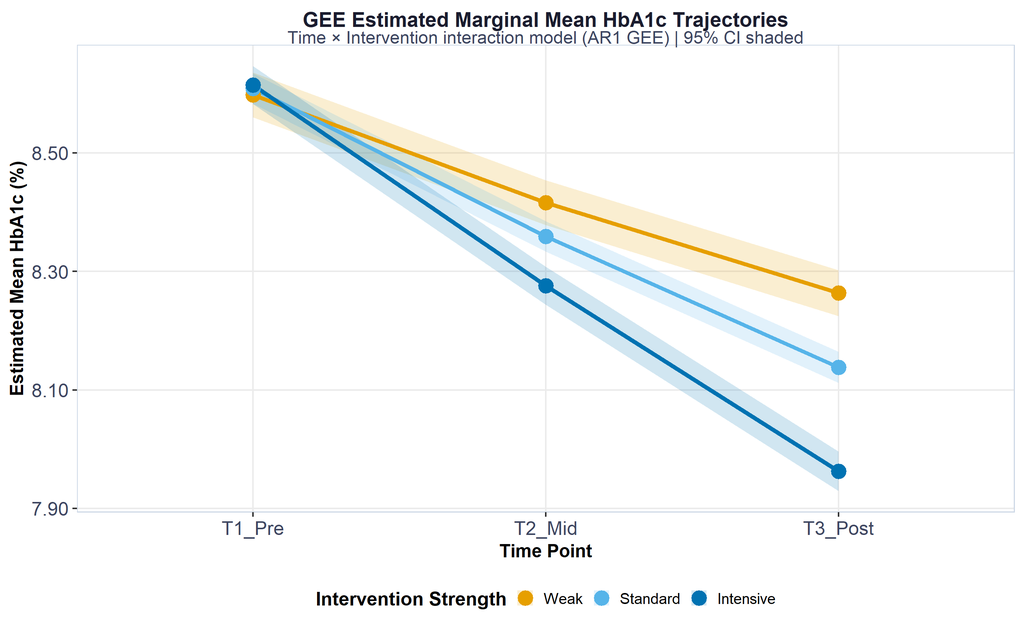

Figure 9: Figure 10. GEE estimated marginal mean HbA1c trajectories by intervention strength (AR(1) interaction model; 95% CI shaded). Non-parallel lines confirm significant Time × Intervention interaction. The Intensive group (cobalt blue) achieves the lowest HbA1c at T3_Post.

```r
ggplot(emm_df,
       aes(x      = time_step,
           y      = emmean,
           group  = intervention_strength,
           colour = intervention_strength,
           fill   = intervention_strength)) +
  geom_ribbon(aes(ymin = .data[[ci_lo]], ymax = .data[[ci_hi]]),
              alpha = 0.18, colour = NA) +
  geom_line(linewidth = 1.3) +
  geom_point(size = 4) +
  scale_colour_manual(values = cb_intervention, name = "Intervention Strength") +
  scale_fill_manual(values   = cb_intervention, name = "Intervention Strength") +
  scale_y_continuous(labels = scales::number_format(accuracy = 0.01)) +
  labs(
    title    = "GEE Estimated Marginal Mean HbA1c Trajectories",
    subtitle = "Time × Intervention interaction model (AR1 GEE) | 95% CI shaded",
    x        = "Time Point",
    y        = "Estimated Mean HbA1c (%)"
  ) +
  theme_gee()
```

## 4.7 A: Model Diagnostics

### 4.7.1 Pearson Residual Analysis

Traditional influential diagnostics (Cook’s distance, leverage) are derived for independent observations and do not apply directly to GEE. With n = 20,000 clusters, no single patient can meaningfully shift population-averaged estimates. Model adequacy is assessed via Pearson residual plots.

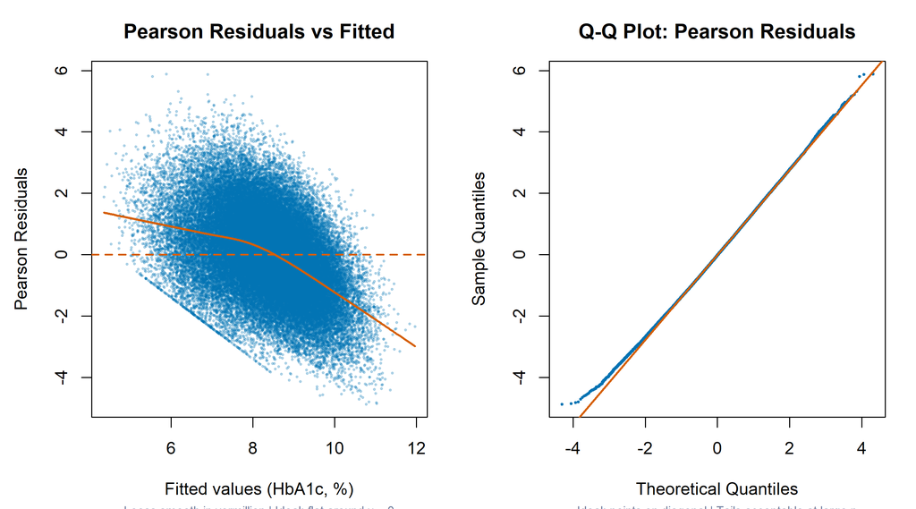

```r
gee_resid  <- residuals(gee_exch, type = "pearson")
gee_fitted <- fitted(gee_exch)

par(mfrow = c(1, 2),
    mar   = c(4.5, 4.5, 3, 1.5),
    family = "sans")

plot(gee_fitted, gee_resid,
     main = "Pearson Residuals vs Fitted",
     xlab = "Fitted values (HbA1c, %)",
     ylab = "Pearson Residuals",
     col  = adjustcolor("#0072B2", 0.22),
     pch  = 20, cex = 0.45)
abline(h = 0, col = "#D55E00", lwd = 1.8, lty = 2)
lines(lowess(gee_fitted, gee_resid), col = "#D55E00", lwd = 2)
mtext("Loess smooth in vermillion | Ideal: flat around y = 0",
      side = 1, line = 4, cex = 0.72, col = "#6b7a99")

qqnorm(gee_resid,
       main = "Q-Q Plot: Pearson Residuals",
       xlab = "Theoretical Quantiles",
       ylab = "Sample Quantiles",
       col  = "#0072B2", pch = 20, cex = 0.45)
qqline(gee_resid, col = "#D55E00", lwd = 2)
mtext("Ideal: points on diagonal | Tails acceptable at large n",
      side = 1, line = 4, cex = 0.72, col = "#6b7a99")

par(mfrow = c(1, 1))
```

**NoteFigure 11 Interpretation**

### 4.7.2 Observed Mean Trajectory Verification

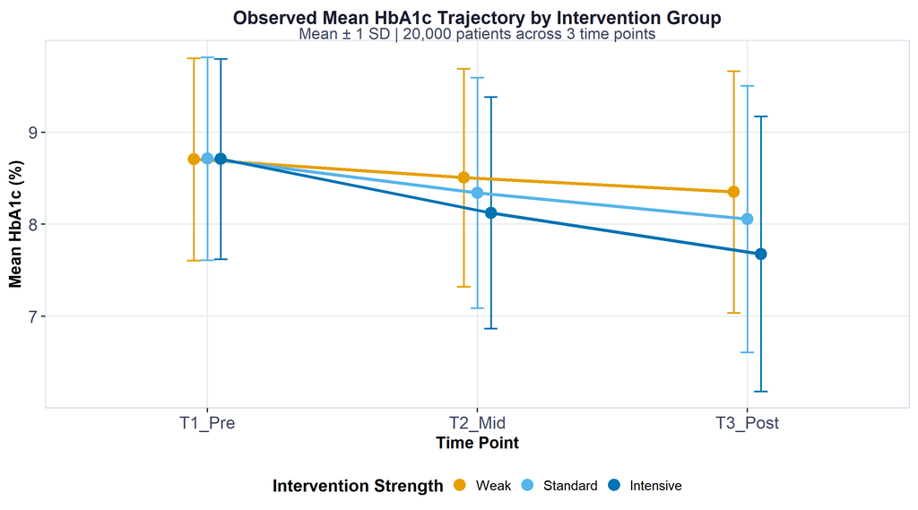

Figure 11: Figure 12. Observed mean HbA1c trajectories (±1 SD) by intervention group. This empirically validates that GEE model-estimated EMMs (Figure 10) faithfully reflect raw data patterns.

```r
df |>
  group_by(time_step, intervention_strength) |>
  summarise(
    mean_hba1c = mean(hba1c),
    sd_hba1c   = sd(hba1c),
    .groups    = "drop"
  ) |>
  ggplot(aes(x      = time_step,
             y      = mean_hba1c,
             group  = intervention_strength,
             colour = intervention_strength)) +
  geom_errorbar(aes(ymin = mean_hba1c - sd_hba1c,
                    ymax = mean_hba1c + sd_hba1c),
                width = 0.15, linewidth = 0.6,
                position = position_dodge(0.15)) +
  geom_line(linewidth = 1.1, position = position_dodge(0.15)) +
  geom_point(size = 3.5, position = position_dodge(0.15)) +
  scale_colour_manual(values = cb_intervention, name = "Intervention Strength") +
  labs(
    title    = "Observed Mean HbA1c Trajectory by Intervention Group",
    subtitle = "Mean ± 1 SD | 20,000 patients across 3 time points",
    x        = "Time Point",
    y        = "Mean HbA1c (%)"
  ) +
  theme_gee()
```